# DS_Project

```python
import numpy as np
import pandas as pd
import matplotlib.pyplot as plt
import seaborn as sns
```

```python
%matplotlib inline
```

```python
df=pd.read_csv('311_Service_Requests_from_2010_to_Present.csv')
```

```python
df.head()
```

|  | Unique Key | Created Date | Closed Date | Agency | Agency Name | Complaint Type | Descriptor | Location Type | Incident Zip | Incident Address | ... | Bridge Highway Name | Bridge Highway Direction | Road Ramp | Bridge Highway Segment | Garage Lot Name | Ferry Direction | Ferry Terminal Name | Latitude | Longitude | Location |
| --- | --- | --- | --- | --- | --- | --- | --- | --- | --- | --- | --- | --- | --- | --- | --- | --- | --- | --- | --- | --- | --- |
| 0 | 32310363 | 12/31/2015 11:59:45 PM | 01-01-16 0:55 | NYPD | New York City Police Department | Noise - Street/Sidewalk | Loud Music/Party | Street/Sidewalk | 10034.0 | 71 VERMILYEA AVENUE | ... | NaN | NaN | NaN | NaN | NaN | NaN | NaN | 40.865682 | -73.923501 | (40.86568153633767, -73.92350095571744) |
| 1 | 32309934 | 12/31/2015 11:59:44 PM | 01-01-16 1:26 | NYPD | New York City Police Department | Blocked Driveway | No Access | Street/Sidewalk | 11105.0 | 27-07 23 AVENUE | ... | NaN | NaN | NaN | NaN | NaN | NaN | NaN | 40.775945 | -73.915094 | (40.775945312321085, -73.91509393898605) |
| 2 | 32309159 | 12/31/2015 11:59:29 PM | 01-01-16 4:51 | NYPD | New York City Police Department | Blocked Driveway | No Access | Street/Sidewalk | 10458.0 | 2897 VALENTINE AVENUE | ... | NaN | NaN | NaN | NaN | NaN | NaN | NaN | 40.870325 | -73.888525 | (40.870324522111424, -73.88852464418646) |
| 3 | 32305098 | 12/31/2015 11:57:46 PM | 01-01-16 7:43 | NYPD | New York City Police Department | Illegal Parking | Commercial Overnight Parking | Street/Sidewalk | 10461.0 | 2940 BAISLEY AVENUE | ... | NaN | NaN | NaN | NaN | NaN | NaN | NaN | 40.835994 | -73.828379 | (40.83599404683083, -73.82837939584206) |
| 4 | 32306529 | 12/31/2015 11:56:58 PM | 01-01-16 3:24 | NYPD | New York City Police Department | Illegal Parking | Blocked Sidewalk | Street/Sidewalk | 11373.0 | 87-14 57 ROAD | ... | NaN | NaN | NaN | NaN | NaN | NaN | NaN | 40.733060 | -73.874170 | (40.733059618956815, -73.87416975810375) |

5 rows × 53 columns

```python
df.describe()
```

|  | Unique Key | Incident Zip | X Coordinate (State Plane) | Y Coordinate (State Plane) | School or Citywide Complaint | Vehicle Type | Taxi Company Borough | Taxi Pick Up Location | Garage Lot Name | Latitude | Longitude |
| --- | --- | --- | --- | --- | --- | --- | --- | --- | --- | --- | --- |
| count | 3.006980e+05 | 298083.000000 | 2.971580e+05 | 297158.000000 | 0.0 | 0.0 | 0.0 | 0.0 | 0.0 | 297158.000000 | 297158.000000 |
| mean | 3.130054e+07 | 10848.888645 | 1.004854e+06 | 203754.534416 | NaN | NaN | NaN | NaN | NaN | 40.725885 | -73.925630 |
| std | 5.738547e+05 | 583.182081 | 2.175338e+04 | 29880.183529 | NaN | NaN | NaN | NaN | NaN | 0.082012 | 0.078454 |
| min | 3.027948e+07 | 83.000000 | 9.133570e+05 | 121219.000000 | NaN | NaN | NaN | NaN | NaN | 40.499135 | -74.254937 |
| 25% | 3.080118e+07 | 10310.000000 | 9.919752e+05 | 183343.000000 | NaN | NaN | NaN | NaN | NaN | 40.669796 | -73.972142 |
| 50% | 3.130436e+07 | 11208.000000 | 1.003158e+06 | 201110.500000 | NaN | NaN | NaN | NaN | NaN | 40.718661 | -73.931781 |
| 75% | 3.178446e+07 | 11238.000000 | 1.018372e+06 | 224125.250000 | NaN | NaN | NaN | NaN | NaN | 40.781840 | -73.876805 |
| max | 3.231065e+07 | 11697.000000 | 1.067173e+06 | 271876.000000 | NaN | NaN | NaN | NaN | NaN | 40.912869 | -73.700760 |

```python
df.info()
```

```
<class 'pandas.core.frame.DataFrame'>
RangeIndex: 300698 entries, 0 to 300697
Data columns (total 53 columns):
Unique Key                        300698 non-null int64
Created Date                      300698 non-null object
Closed Date                       298534 non-null object
Agency                            300698 non-null object
Agency Name                       300698 non-null object
Complaint Type                    300698 non-null object
Descriptor                        294784 non-null object
Location Type                     300567 non-null object
Incident Zip                      298083 non-null float64
Incident Address                  256288 non-null object
Street Name                       256288 non-null object
Cross Street 1                    251419 non-null object
Cross Street 2                    250919 non-null object
Intersection Street 1             43858 non-null object
Intersection Street 2             43362 non-null object
Address Type                      297883 non-null object
City                              298084 non-null object
Landmark                          349 non-null object
Facility Type                     298527 non-null object
Status                            300698 non-null object
Due Date                          300695 non-null object
Resolution Description            300698 non-null object
Resolution Action Updated Date    298511 non-null object
Community Board                   300698 non-null object
Borough                           300698 non-null object
X Coordinate (State Plane)        297158 non-null float64
Y Coordinate (State Plane)        297158 non-null float64
Park Facility Name                300698 non-null object
Park Borough                      300698 non-null object
School Name                       300698 non-null object
School Number                     300698 non-null object
School Region                     300697 non-null object
School Code                       300697 non-null object
School Phone Number               300698 non-null object
School Address                    300698 non-null object
School City                       300698 non-null object
School State                      300698 non-null object
School Zip                        300697 non-null object
School Not Found                  300698 non-null object
School or Citywide Complaint      0 non-null float64
Vehicle Type                      0 non-null float64
Taxi Company Borough              0 non-null float64
Taxi Pick Up Location             0 non-null float64
Bridge Highway Name               243 non-null object
Bridge Highway Direction          243 non-null object
Road Ramp                         213 non-null object
Bridge Highway Segment            213 non-null object
Garage Lot Name                   0 non-null float64
Ferry Direction                   1 non-null object
Ferry Terminal Name               2 non-null object
Latitude                          297158 non-null float64
Longitude                         297158 non-null float64
Location                          297158 non-null object
dtypes: float64(10), int64(1), object(42)
memory usage: 121.6+ MB
```

# First we need to convert both the created date and closed date into datetime objects

```python
df['Created Date']=pd.to_datetime(df['Created Date'])
```

```python
df['Closed Date']=pd.to_datetime(df['Closed Date'])
```

```python
df['Request_Closing_Time']=df['Closed Date']-df['Created Date']
```

```python
df
```

|  | Unique Key | Created Date | Closed Date | Agency | Agency Name | Complaint Type | Descriptor | Location Type | Incident Zip | Incident Address | ... | Bridge Highway Direction | Road Ramp | Bridge Highway Segment | Garage Lot Name | Ferry Direction | Ferry Terminal Name | Latitude | Longitude | Location | Request_Closing_Time |
| --- | --- | --- | --- | --- | --- | --- | --- | --- | --- | --- | --- | --- | --- | --- | --- | --- | --- | --- | --- | --- | --- |
| 0 | 32310363 | 2015-12-31 23:59:45 | 2016-01-01 00:55:00 | NYPD | New York City Police Department | Noise - Street/Sidewalk | Loud Music/Party | Street/Sidewalk | 10034.0 | 71 VERMILYEA AVENUE | ... | NaN | NaN | NaN | NaN | NaN | NaN | 40.865682 | -73.923501 | (40.86568153633767, -73.92350095571744) | 0 days 00:55:15 |
| 1 | 32309934 | 2015-12-31 23:59:44 | 2016-01-01 01:26:00 | NYPD | New York City Police Department | Blocked Driveway | No Access | Street/Sidewalk | 11105.0 | 27-07 23 AVENUE | ... | NaN | NaN | NaN | NaN | NaN | NaN | 40.775945 | -73.915094 | (40.775945312321085, -73.91509393898605) | 0 days 01:26:16 |
| 2 | 32309159 | 2015-12-31 23:59:29 | 2016-01-01 04:51:00 | NYPD | New York City Police Department | Blocked Driveway | No Access | Street/Sidewalk | 10458.0 | 2897 VALENTINE AVENUE | ... | NaN | NaN | NaN | NaN | NaN | NaN | 40.870325 | -73.888525 | (40.870324522111424, -73.88852464418646) | 0 days 04:51:31 |
| 3 | 32305098 | 2015-12-31 23:57:46 | 2016-01-01 07:43:00 | NYPD | New York City Police Department | Illegal Parking | Commercial Overnight Parking | Street/Sidewalk | 10461.0 | 2940 BAISLEY AVENUE | ... | NaN | NaN | NaN | NaN | NaN | NaN | 40.835994 | -73.828379 | (40.83599404683083, -73.82837939584206) | 0 days 07:45:14 |
| 4 | 32306529 | 2015-12-31 23:56:58 | 2016-01-01 03:24:00 | NYPD | New York City Police Department | Illegal Parking | Blocked Sidewalk | Street/Sidewalk | 11373.0 | 87-14 57 ROAD | ... | NaN | NaN | NaN | NaN | NaN | NaN | 40.733060 | -73.874170 | (40.733059618956815, -73.87416975810375) | 0 days 03:27:02 |
| 5 | 32306554 | 2015-12-31 23:56:30 | 2016-01-01 01:50:00 | NYPD | New York City Police Department | Illegal Parking | Posted Parking Sign Violation | Street/Sidewalk | 11215.0 | 260 21 STREET | ... | NaN | NaN | NaN | NaN | NaN | NaN | 40.660823 | -73.992568 | (40.66082272389114, -73.99256786342693) | 0 days 01:53:30 |
| 6 | 32306559 | 2015-12-31 23:55:32 | 2016-01-01 01:53:00 | NYPD | New York City Police Department | Illegal Parking | Blocked Hydrant | Street/Sidewalk | 10032.0 | 524 WEST 169 STREET | ... | NaN | NaN | NaN | NaN | NaN | NaN | 40.840848 | -73.937375 | (40.840847591440415, -73.9373750864581) | 0 days 01:57:28 |
| 7 | 32307009 | 2015-12-31 23:54:05 | 2016-01-01 01:42:00 | NYPD | New York City Police Department | Blocked Driveway | No Access | Street/Sidewalk | 10457.0 | 501 EAST 171 STREET | ... | NaN | NaN | NaN | NaN | NaN | NaN | 40.837503 | -73.902905 | (40.83750262540012, -73.90290517326568) | 0 days 01:47:55 |
| 8 | 32308581 | 2015-12-31 23:53:58 | 2016-01-01 08:27:00 | NYPD | New York City Police Department | Illegal Parking | Posted Parking Sign Violation | Street/Sidewalk | 11415.0 | 83-44 LEFFERTS BOULEVARD | ... | NaN | NaN | NaN | NaN | NaN | NaN | 40.704977 | -73.832605 | (40.704977164399935, -73.8326047502584) | 0 days 08:33:02 |
| 9 | 32308391 | 2015-12-31 23:53:58 | 2016-01-01 01:17:00 | NYPD | New York City Police Department | Blocked Driveway | No Access | Street/Sidewalk | 11219.0 | 1408 66 STREET | ... | NaN | NaN | NaN | NaN | NaN | NaN | 40.623793 | -73.999539 | (40.623793065806524, -73.99953890121567) | 0 days 01:23:02 |
| 10 | 32305071 | 2015-12-31 23:52:58 | 2016-01-01 07:41:00 | NYPD | New York City Police Department | Blocked Driveway | No Access | Street/Sidewalk | 11372.0 | 34-06 73 STREET | ... | NaN | NaN | NaN | NaN | NaN | NaN | 40.752600 | -73.893363 | (40.752599671969676, -73.8933632141368) | 0 days 07:48:02 |
| 11 | 32306260 | 2015-12-31 23:50:57 | 2016-01-01 10:58:00 | NYPD | New York City Police Department | Blocked Driveway | No Access | Street/Sidewalk | 10453.0 | 1770 UNDERCLIFF AVENUE | ... | NaN | NaN | NaN | NaN | NaN | NaN | 40.851555 | -73.919997 | (40.85155492779258, -73.91999651358469) | 0 days 11:07:03 |
| 12 | 32306612 | 2015-12-31 23:48:03 | 2016-01-01 02:17:00 | NYPD | New York City Police Department | Noise - Street/Sidewalk | Loud Music/Party | Street/Sidewalk | 10461.0 | 1701 PILGRIM AVENUE | ... | NaN | NaN | NaN | NaN | NaN | NaN | 40.845545 | -73.833585 | (40.845545043640215, -73.83358471831198) | 0 days 02:28:57 |
| 13 | 32305074 | 2015-12-31 23:47:58 | 2016-01-01 08:18:00 | NYPD | New York City Police Department | Illegal Parking | Posted Parking Sign Violation | Street/Sidewalk | 11208.0 | 38 COX PLACE | ... | NaN | NaN | NaN | NaN | NaN | NaN | 40.687511 | -73.874505 | (40.68751060232221, -73.87450451131276) | 0 days 08:30:02 |
| 14 | 32309424 | 2015-12-31 23:47:37 | 2016-01-01 10:17:00 | NYPD | New York City Police Department | Derelict Vehicle | With License Plate | Street/Sidewalk | 11379.0 | 62-13 62 AVENUE | ... | NaN | NaN | NaN | NaN | NaN | NaN | 40.714093 | -73.899384 | (40.71409341858147, -73.89938394187791) | 0 days 10:29:23 |
| 15 | 32309853 | 2015-12-31 23:47:30 | 2016-01-01 15:20:00 | NYPD | New York City Police Department | Blocked Driveway | Partial Access | Street/Sidewalk | 11374.0 | 61-34 AUSTIN STREET | ... | NaN | NaN | NaN | NaN | NaN | NaN | 40.729679 | -73.870417 | (40.72967940444622, -73.87041654016662) | 0 days 15:32:30 |
| 16 | 32305538 | 2015-12-31 23:47:02 | 2016-01-01 04:39:00 | NYPD | New York City Police Department | Blocked Driveway | No Access | Street/Sidewalk | 11412.0 | 192-05 LINDEN BOULEVARD | ... | NaN | NaN | NaN | NaN | NaN | NaN | 40.692520 | -73.759264 | (40.69252034680599, -73.75926357603389) | 0 days 04:51:58 |
| 17 | 32310273 | 2015-12-31 23:44:52 | 2016-01-01 00:36:00 | NYPD | New York City Police Department | Noise - Commercial | Loud Music/Party | Club/Bar/Restaurant | 11217.0 | 622 DEGRAW STREET | ... | NaN | NaN | NaN | NaN | NaN | NaN | 40.679154 | -73.983430 | (40.679154133157326, -73.98342992763081) | 0 days 00:51:08 |
| 18 | 32306617 | 2015-12-31 23:40:59 | 2016-01-01 02:37:00 | NYPD | New York City Police Department | Noise - Commercial | Loud Music/Party | Club/Bar/Restaurant | 11234.0 | 2192 FLATBUSH AVENUE | ... | NaN | NaN | NaN | NaN | NaN | NaN | 40.616550 | -73.930202 | (40.61655032892211, -73.93020153359745) | 0 days 02:56:01 |
| 19 | 32308195 | 2015-12-31 23:40:55 | 2016-01-01 00:28:00 | NYPD | New York City Police Department | Noise - Street/Sidewalk | Loud Music/Party | Street/Sidewalk | 10026.0 | 264 WEST 118 STREET | ... | NaN | NaN | NaN | NaN | NaN | NaN | 40.805267 | -73.953353 | (40.80526715877265, -73.9533526205901) | 0 days 00:47:05 |
| 20 | 32310127 | 2015-12-31 23:40:43 | 2016-01-01 04:12:00 | NYPD | New York City Police Department | Illegal Parking | Unauthorized Bus Layover | Street/Sidewalk | 10456.0 | 1417 WEBSTER AVENUE | ... | NaN | NaN | NaN | NaN | NaN | NaN | 40.836727 | -73.907106 | (40.83672658684552, -73.90710561784778) | 0 days 04:31:17 |
| 21 | 32307994 | 2015-12-31 23:38:51 | 2016-01-01 09:11:00 | NYPD | New York City Police Department | Illegal Parking | Posted Parking Sign Violation | Street/Sidewalk | 11379.0 | 78-42 METROPOLITAN AVENUE | ... | NaN | NaN | NaN | NaN | NaN | NaN | 40.713198 | -73.874139 | (40.713198496024376, -73.87413871579652) | 0 days 09:32:09 |
| 22 | 32307233 | 2015-12-31 23:34:18 | 2016-01-01 00:50:00 | NYPD | New York City Police Department | Noise - Commercial | Loud Music/Party | Store/Commercial | 11234.0 | 3622 QUENTIN ROAD | ... | NaN | NaN | NaN | NaN | NaN | NaN | 40.614784 | -73.936568 | (40.61478362623815, -73.93656784825214) | 0 days 01:15:42 |
| 23 | 32308765 | 2015-12-31 23:32:46 | 2016-01-01 00:25:00 | NYPD | New York City Police Department | Illegal Parking | Double Parked Blocking Vehicle | Street/Sidewalk | 10030.0 | 133 WEST 134 STREET | ... | NaN | NaN | NaN | NaN | NaN | NaN | 40.814002 | -73.942664 | (40.814001537165495, -73.94266395083876) | 0 days 00:52:14 |
| 24 | 32308423 | 2015-12-31 23:31:40 | 2016-01-03 16:22:00 | NYPD | New York City Police Department | Blocked Driveway | No Access | Street/Sidewalk | 10467.0 | 3025 WALLACE AVENUE | ... | NaN | NaN | NaN | NaN | NaN | NaN | 40.870063 | -73.864322 | (40.87006255915965, -73.86432172842636) | 2 days 16:50:20 |
| 25 | 32308426 | 2015-12-31 23:30:28 | 2016-01-01 02:47:00 | NYPD | New York City Police Department | Blocked Driveway | No Access | Street/Sidewalk | 11432.0 | 175-18 90 AVENUE | ... | NaN | NaN | NaN | NaN | NaN | NaN | 40.709827 | -73.786257 | (40.70982729683097, -73.78625714739626) | 0 days 03:16:32 |
| 26 | 32305916 | 2015-12-31 23:26:41 | 2015-12-31 23:53:31 | NYPD | New York City Police Department | Noise - House of Worship | Loud Music/Party | House of Worship | 10031.0 | 452 WEST 147 STREET | ... | NaN | NaN | NaN | NaN | NaN | NaN | 40.826102 | -73.945663 | (40.826101709196, -73.94566339279595) | 0 days 00:26:50 |
| 27 | 32308379 | 2015-12-31 23:26:35 | 2016-01-01 05:07:00 | NYPD | New York City Police Department | Blocked Driveway | No Access | Street/Sidewalk | 11419.0 | 103-28 118 STREET | ... | NaN | NaN | NaN | NaN | NaN | NaN | 40.687117 | -73.825597 | (40.68711749970851, -73.8255967145633) | 0 days 05:40:25 |
| 28 | 32309402 | 2015-12-31 23:25:56 | 2016-01-01 01:12:00 | NYPD | New York City Police Department | Illegal Parking | Posted Parking Sign Violation | Street/Sidewalk | 10024.0 | 131 WEST 86 STREET | ... | NaN | NaN | NaN | NaN | NaN | NaN | 40.786930 | -73.973202 | (40.78693045941381, -73.9732015755585) | 0 days 01:46:04 |
| 29 | 32308850 | 2015-12-31 23:25:01 | 2016-01-01 01:55:00 | NYPD | New York City Police Department | Noise - Commercial | Loud Music/Party | Club/Bar/Restaurant | 11201.0 | 216 DUFFIELD STREET | ... | NaN | NaN | NaN | NaN | NaN | NaN | 40.691599 | -73.984379 | (40.691599059545375, -73.98437881826075) | 0 days 02:29:59 |
| ... | ... | ... | ... | ... | ... | ... | ... | ... | ... | ... | ... | ... | ... | ... | ... | ... | ... | ... | ... | ... | ... |
| 300668 | 30282107 | 2015-03-29 01:03:20 | 2015-03-29 03:40:19 | NYPD | New York City Police Department | Noise - Commercial | Loud Music/Party | Club/Bar/Restaurant | 11216.0 | 305 HALSEY STREET | ... | NaN | NaN | NaN | NaN | NaN | NaN | 40.682906 | -73.940357 | (40.68290569745191, -73.94035735919954) | 0 days 02:36:59 |
| 300669 | 30283741 | 2015-03-29 01:02:05 | 2015-03-29 05:26:38 | NYPD | New York City Police Department | Noise - Street/Sidewalk | Loud Music/Party | Street/Sidewalk | 10031.0 | NaN | ... | NaN | NaN | NaN | NaN | NaN | NaN | 40.821446 | -73.950379 | (40.82144605015569, -73.95037859121894) | 0 days 04:24:33 |
| 300670 | 30284125 | 2015-03-29 01:01:25 | 2015-03-29 09:26:52 | NYPD | New York City Police Department | Illegal Parking | Blocked Hydrant | Street/Sidewalk | 11354.0 | 33-16 143 STREET | ... | NaN | NaN | NaN | NaN | NaN | NaN | 40.767869 | -73.826216 | (40.767869319511156, -73.82621558171721) | 0 days 08:25:27 |
| 300671 | 30283901 | 2015-03-29 00:58:08 | 2015-03-29 04:44:02 | NYPD | New York City Police Department | Illegal Parking | Blocked Hydrant | Street/Sidewalk | 10019.0 | 446 WEST 49 STREET | ... | NaN | NaN | NaN | NaN | NaN | NaN | 40.763425 | -73.990766 | (40.76342452850363, -73.99076591082245) | 0 days 03:45:54 |
| 300672 | 30282374 | 2015-03-29 00:57:27 | 2015-03-29 16:39:53 | NYPD | New York City Police Department | Blocked Driveway | No Access | Street/Sidewalk | 11208.0 | 326 MCKINLEY AVENUE | ... | NaN | NaN | NaN | NaN | NaN | NaN | 40.681068 | -73.863917 | (40.68106756068015, -73.8639166657132) | 0 days 15:42:26 |
| 300673 | 30280817 | 2015-03-29 00:57:25 | 2015-03-29 02:25:31 | NYPD | New York City Police Department | Noise - Commercial | Loud Music/Party | Club/Bar/Restaurant | 11203.0 | 196 EAST 51 STREET | ... | NaN | NaN | NaN | NaN | NaN | NaN | 40.657327 | -73.929979 | (40.65732675940293, -73.92997866259482) | 0 days 01:28:06 |
| 300674 | 30283364 | 2015-03-29 00:57:19 | 2015-03-29 03:17:59 | NYPD | New York City Police Department | Noise - Street/Sidewalk | Loud Music/Party | Street/Sidewalk | 10025.0 | 220 WEST 107 STREET | ... | NaN | NaN | NaN | NaN | NaN | NaN | 40.801410 | -73.965947 | (40.80140973782622, -73.96594656979163) | 0 days 02:20:40 |
| 300675 | 30280353 | 2015-03-29 00:56:22 | 2015-03-29 01:57:52 | NYPD | New York City Police Department | Noise - Street/Sidewalk | Loud Music/Party | Street/Sidewalk | 10031.0 | 501 WEST 139 STREET | ... | NaN | NaN | NaN | NaN | NaN | NaN | 40.821561 | -73.950631 | (40.82156143682672, -73.95063141802162) | 0 days 01:01:30 |
| 300676 | 30280974 | 2015-03-29 00:55:56 | 2015-03-29 08:08:27 | NYPD | New York City Police Department | Noise - Commercial | Loud Music/Party | Store/Commercial | 11377.0 | 50 STREET | ... | NaN | NaN | NaN | NaN | NaN | NaN | 40.743181 | -73.914894 | (40.74318114209432, -73.91489390486979) | 0 days 07:12:31 |
| 300677 | 30280622 | 2015-03-29 00:55:33 | 2015-03-29 07:12:39 | NYPD | New York City Police Department | Noise - Commercial | Loud Music/Party | Club/Bar/Restaurant | 11237.0 | 302 IRVING AVENUE | ... | NaN | NaN | NaN | NaN | NaN | NaN | 40.698976 | -73.914319 | (40.698976356744375, -73.91431921502723) | 0 days 06:17:06 |
| 300678 | 30282979 | 2015-03-29 00:50:12 | 2015-03-29 07:06:29 | NYPD | New York City Police Department | Noise - Vehicle | Car/Truck Music | Street/Sidewalk | 11206.0 | 29 LOCUST STREET | ... | NaN | NaN | NaN | NaN | NaN | NaN | 40.699334 | -73.937486 | (40.699334367421585, -73.93748637968389) | 0 days 06:16:17 |
| 300679 | 30281254 | 2015-03-29 00:49:51 | 2015-03-29 02:02:21 | NYPD | New York City Police Department | Blocked Driveway | No Access | Street/Sidewalk | 11385.0 | 1912 GROVE STREET | ... | NaN | NaN | NaN | NaN | NaN | NaN | 40.706475 | -73.907504 | (40.70647527382003, -73.90750353701854) | 0 days 01:12:30 |
| 300680 | 30281090 | 2015-03-29 00:49:27 | 2015-03-29 04:25:53 | NYPD | New York City Police Department | Noise - Vehicle | Car/Truck Music | Street/Sidewalk | 10028.0 | 420 EAST 86 STREET | ... | NaN | NaN | NaN | NaN | NaN | NaN | 40.776591 | -73.948719 | (40.776590982604596, -73.94871864443712) | 0 days 03:36:26 |
| 300681 | 30283933 | 2015-03-29 00:48:23 | 2015-03-29 03:42:33 | NYPD | New York City Police Department | Noise - Street/Sidewalk | Loud Music/Party | Street/Sidewalk | 11238.0 | 799 DEAN STREET | ... | NaN | NaN | NaN | NaN | NaN | NaN | 40.679237 | -73.963355 | (40.679237323783724, -73.96335543308066) | 0 days 02:54:10 |
| 300682 | 30283186 | 2015-03-29 00:46:26 | 2015-03-29 07:12:20 | NYPD | New York City Police Department | Noise - Commercial | Loud Music/Party | Club/Bar/Restaurant | 11249.0 | 98A SOUTH 4 STREET | ... | NaN | NaN | NaN | NaN | NaN | NaN | 40.712285 | -73.964001 | (40.712284534374824, -73.96400097454304) | 0 days 06:25:54 |
| 300683 | 30284534 | 2015-03-29 00:44:36 | 2015-03-29 03:40:20 | NYPD | New York City Police Department | Noise - Street/Sidewalk | Loud Talking | Street/Sidewalk | 11238.0 | 801 DEAN STREET | ... | NaN | NaN | NaN | NaN | NaN | NaN | 40.679226 | -73.963309 | (40.67922632975442, -73.96330856984594) | 0 days 02:55:44 |
| 300684 | 30281081 | 2015-03-29 00:43:20 | 2015-03-29 01:10:55 | NYPD | New York City Police Department | Noise - Commercial | Loud Music/Party | Store/Commercial | 10002.0 | 9 STANTON STREET | ... | NaN | NaN | NaN | NaN | NaN | NaN | 40.722621 | -73.992435 | (40.722621191327846, -73.99243470311887) | 0 days 00:27:35 |
| 300685 | 30280506 | 2015-03-29 00:43:16 | 2015-03-29 04:25:50 | NYPD | New York City Police Department | Noise - Vehicle | Car/Truck Music | Street/Sidewalk | 10028.0 | 415 EAST 86 STREET | ... | NaN | NaN | NaN | NaN | NaN | NaN | 40.776646 | -73.948805 | (40.77664591586459, -73.94880525662063) | 0 days 03:42:34 |
| 300686 | 30281145 | 2015-03-29 00:43:06 | 2015-03-29 00:57:23 | NYPD | New York City Police Department | Noise - Commercial | Loud Music/Party | Store/Commercial | 10014.0 | 185 CHRISTOPHER STREET | ... | NaN | NaN | NaN | NaN | NaN | NaN | 40.732486 | -74.009688 | (40.73248568650513, -74.00968804444769) | 0 days 00:14:17 |
| 300687 | 30282599 | 2015-03-29 00:42:48 | 2015-03-29 02:57:41 | NYPD | New York City Police Department | Blocked Driveway | No Access | Street/Sidewalk | 11385.0 | 77-03 79 PLACE | ... | NaN | NaN | NaN | NaN | NaN | NaN | 40.706353 | -73.871245 | (40.70635259429073, -73.8712445609601) | 0 days 02:14:53 |
| 300688 | 30280732 | 2015-03-29 00:37:15 | 2015-03-29 01:02:39 | NYPD | New York City Police Department | Noise - Commercial | Loud Music/Party | Club/Bar/Restaurant | 10014.0 | 22 9 AVENUE | ... | NaN | NaN | NaN | NaN | NaN | NaN | 40.740361 | -74.005781 | (40.74036064515079, -74.00578103597579) | 0 days 00:25:24 |
| 300689 | 30283432 | 2015-03-29 00:35:28 | 2015-03-29 04:14:27 | NYPD | New York City Police Department | Noise - Street/Sidewalk | Loud Music/Party | Street/Sidewalk | 11233.0 | 120 CHAUNCEY STREET | ... | NaN | NaN | NaN | NaN | NaN | NaN | 40.680399 | -73.929417 | (40.6803990181202, -73.92941723335176) | 0 days 03:38:59 |
| 300690 | 30280538 | 2015-03-29 00:35:23 | 2015-03-29 08:41:24 | NYPD | New York City Police Department | Illegal Parking | Commercial Overnight Parking | Street/Sidewalk | 10466.0 | NaN | ... | NaN | NaN | NaN | NaN | NaN | NaN | 40.900403 | -73.840809 | (40.90040252667784, -73.84080863767632) | 0 days 08:06:01 |
| 300691 | 30279999 | 2015-03-29 00:35:04 | 2015-03-29 02:52:28 | NYPD | New York City Police Department | Noise - Commercial | Loud Music/Party | Store/Commercial | 10034.0 | 97 SHERMAN AVENUE | ... | NaN | NaN | NaN | NaN | NaN | NaN | 40.863805 | -73.925358 | (40.863805379005, -73.92535778152539) | 0 days 02:17:24 |
| 300692 | 30281370 | 2015-03-29 00:34:32 | 2015-03-29 01:13:01 | NYPD | New York City Police Department | Noise - Commercial | Loud Music/Party | Store/Commercial | 10002.0 | 81 HESTER STREET | ... | NaN | NaN | NaN | NaN | NaN | NaN | 40.716053 | -73.991378 | (40.71605290789855, -73.99137850370803) | 0 days 00:38:29 |
| 300693 | 30281872 | 2015-03-29 00:33:41 | NaT | NYPD | New York City Police Department | Noise - Commercial | Loud Music/Party | Club/Bar/Restaurant | NaN | CRESCENT AVENUE | ... | NaN | NaN | NaN | NaN | NaN | NaN | NaN | NaN | NaN | NaT |
| 300694 | 30281230 | 2015-03-29 00:33:28 | 2015-03-29 02:33:59 | NYPD | New York City Police Department | Blocked Driveway | Partial Access | Street/Sidewalk | 11418.0 | 100-17 87 AVENUE | ... | NaN | NaN | NaN | NaN | NaN | NaN | 40.694077 | -73.846087 | (40.69407728322387, -73.8460866160573) | 0 days 02:00:31 |
| 300695 | 30283424 | 2015-03-29 00:33:03 | 2015-03-29 03:40:20 | NYPD | New York City Police Department | Noise - Commercial | Loud Music/Party | Club/Bar/Restaurant | 11206.0 | 162 THROOP AVENUE | ... | NaN | NaN | NaN | NaN | NaN | NaN | 40.699590 | -73.944234 | (40.69959035300927, -73.94423377144169) | 0 days 03:07:17 |
| 300696 | 30280004 | 2015-03-29 00:33:02 | 2015-03-29 04:38:35 | NYPD | New York City Police Department | Noise - Commercial | Loud Music/Party | Club/Bar/Restaurant | 10461.0 | 3151 EAST TREMONT AVENUE | ... | NaN | NaN | NaN | NaN | NaN | NaN | 40.837708 | -73.834587 | (40.8377075854206, -73.83458731019586) | 0 days 04:05:33 |
| 300697 | 30281825 | 2015-03-29 00:33:01 | 2015-03-29 04:41:50 | NYPD | New York City Police Department | Noise - Commercial | Loud Music/Party | Store/Commercial | 10036.0 | 251 WEST 48 STREET | ... | NaN | NaN | NaN | NaN | NaN | NaN | 40.760583 | -73.985922 | (40.76058322950115, -73.98592204392392) | 0 days 04:08:49 |

300698 rows × 54 columns

```python
#Visuallizing missing values
```

```python
df.isnull().sum()
```

```
Unique Key                             0
Created Date                           0
Closed Date                         2164
Agency                                 0
Agency Name                            0
Complaint Type                         0
Descriptor                          5914
Location Type                        131
Incident Zip                        2615
Incident Address                   44410
Street Name                        44410
Cross Street 1                     49279
Cross Street 2                     49779
Intersection Street 1             256840
Intersection Street 2             257336
Address Type                        2815
City                                2614
Landmark                          300349
Facility Type                       2171
Status                                 0
Due Date                               3
Resolution Description                 0
Resolution Action Updated Date      2187
Community Board                        0
Borough                                0
X Coordinate (State Plane)          3540
Y Coordinate (State Plane)          3540
Park Facility Name                     0
Park Borough                           0
School Name                            0
School Number                          0
School Region                          1
School Code                            1
School Phone Number                    0
School Address                         0
School City                            0
School State                           0
School Zip                             1
School Not Found                       0
School or Citywide Complaint      300698
Vehicle Type                      300698
Taxi Company Borough              300698
Taxi Pick Up Location             300698
Bridge Highway Name               300455
Bridge Highway Direction          300455
Road Ramp                         300485
Bridge Highway Segment            300485
Garage Lot Name                   300698
Ferry Direction                   300697
Ferry Terminal Name               300696
Latitude                            3540
Longitude                           3540
Location                            3540
Request_Closing_Time                2164
dtype: int64
```

```python
#we can also find the percentage of missing values in relation to the number of records as follows:

df.isnull().mean()*100
```

```
Unique Key                          0.000000
Created Date                        0.000000
Closed Date                         0.719659
Agency                              0.000000
Agency Name                         0.000000
Complaint Type                      0.000000
Descriptor                          1.966757
Location Type                       0.043565
Incident Zip                        0.869643
Incident Address                   14.768971
Street Name                        14.768971
Cross Street 1                     16.388203
Cross Street 2                     16.554483
Intersection Street 1              85.414602
Intersection Street 2              85.579552
Address Type                        0.936155
City                                0.869311
Landmark                           99.883937
Facility Type                       0.721987
Status                              0.000000
Due Date                            0.000998
Resolution Description              0.000000
Resolution Action Updated Date      0.727308
Community Board                     0.000000
Borough                             0.000000
X Coordinate (State Plane)          1.177261
Y Coordinate (State Plane)          1.177261
Park Facility Name                  0.000000
Park Borough                        0.000000
School Name                         0.000000
School Number                       0.000000
School Region                       0.000333
School Code                         0.000333
School Phone Number                 0.000000
School Address                      0.000000
School City                         0.000000
School State                        0.000000
School Zip                          0.000333
School Not Found                    0.000000
School or Citywide Complaint      100.000000
Vehicle Type                      100.000000
Taxi Company Borough              100.000000
Taxi Pick Up Location             100.000000
Bridge Highway Name                99.919188
Bridge Highway Direction           99.919188
Road Ramp                          99.929165
Bridge Highway Segment             99.929165
Garage Lot Name                   100.000000
Ferry Direction                    99.999667
Ferry Terminal Name                99.999335
Latitude                            1.177261
Longitude                           1.177261
Location                            1.177261
Request_Closing_Time                0.719659
dtype: float64
```

```python
import missingno as msno
```

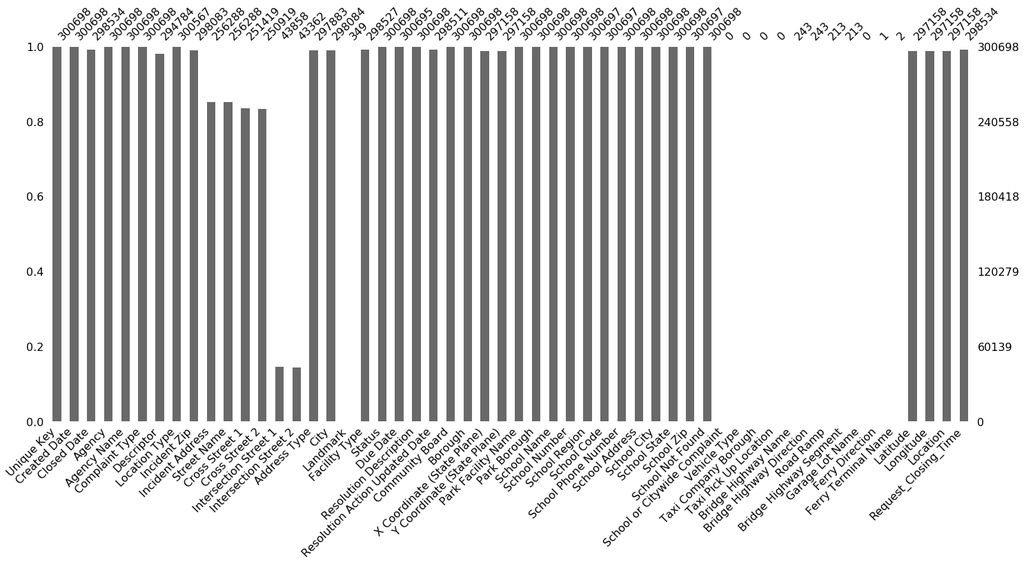

```python
msno.bar(df,labels=df.all)# This shows visually the columns with the non-null values and the missing null values!
```

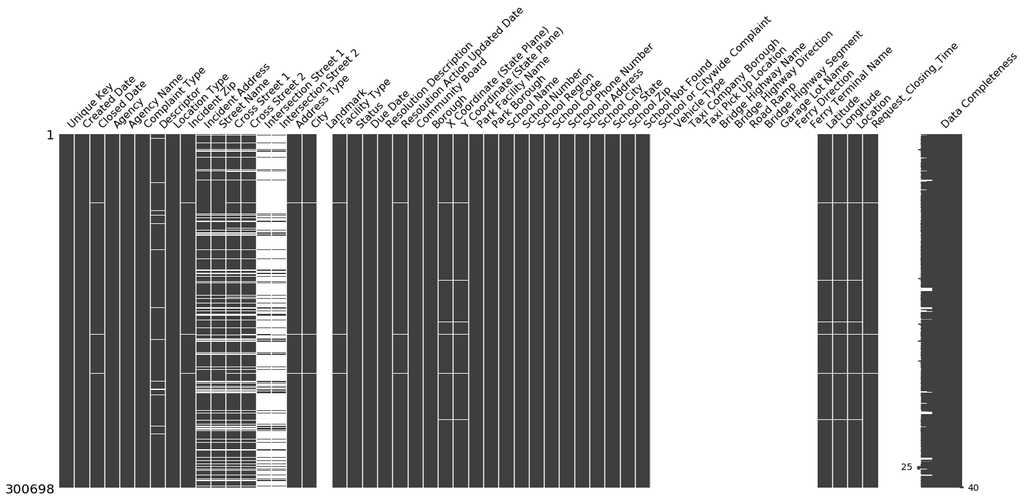

```python
msno.matrix(df,labels=df.all)# This shows were the null values are dispersed along the dataset
```

```python
df.shape
```

```
(300698, 54)
```

```python
#So we can come to the conclusion that we need to drop the features with majority of the records are of null values!!
```

```python
list_to_drop=['Intersection Street 1','Intersection Street 2','Landmark','School or Citywide Complaint','Vehicle Type','Taxi Company Borough','Taxi Pick Up Location','Bridge Highway Name','Bridge Highway Direction','Road Ramp','Bridge Highway Segment','Garage Lot Name','Ferry Direction','Ferry Terminal Name']
```

```python
df_new=df.drop(list_to_drop,axis=1)
```

```python
df_new.shape
```

```
(300698, 40)
```

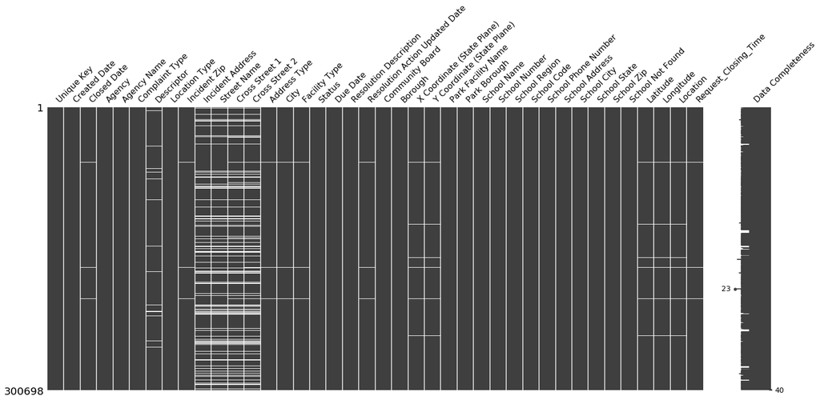

```python
msno.matrix(df_new,labels=df_new.all)
```

```python
df_new
```

|  | Unique Key | Created Date | Closed Date | Agency | Agency Name | Complaint Type | Descriptor | Location Type | Incident Zip | Incident Address | ... | School Phone Number | School Address | School City | School State | School Zip | School Not Found | Latitude | Longitude | Location | Request_Closing_Time |
| --- | --- | --- | --- | --- | --- | --- | --- | --- | --- | --- | --- | --- | --- | --- | --- | --- | --- | --- | --- | --- | --- |
| 0 | 32310363 | 2015-12-31 23:59:45 | 2016-01-01 00:55:00 | NYPD | New York City Police Department | Noise - Street/Sidewalk | Loud Music/Party | Street/Sidewalk | 10034.0 | 71 VERMILYEA AVENUE | ... | Unspecified | Unspecified | Unspecified | Unspecified | Unspecified | N | 40.865682 | -73.923501 | (40.86568153633767, -73.92350095571744) | 0 days 00:55:15 |
| 1 | 32309934 | 2015-12-31 23:59:44 | 2016-01-01 01:26:00 | NYPD | New York City Police Department | Blocked Driveway | No Access | Street/Sidewalk | 11105.0 | 27-07 23 AVENUE | ... | Unspecified | Unspecified | Unspecified | Unspecified | Unspecified | N | 40.775945 | -73.915094 | (40.775945312321085, -73.91509393898605) | 0 days 01:26:16 |
| 2 | 32309159 | 2015-12-31 23:59:29 | 2016-01-01 04:51:00 | NYPD | New York City Police Department | Blocked Driveway | No Access | Street/Sidewalk | 10458.0 | 2897 VALENTINE AVENUE | ... | Unspecified | Unspecified | Unspecified | Unspecified | Unspecified | N | 40.870325 | -73.888525 | (40.870324522111424, -73.88852464418646) | 0 days 04:51:31 |
| 3 | 32305098 | 2015-12-31 23:57:46 | 2016-01-01 07:43:00 | NYPD | New York City Police Department | Illegal Parking | Commercial Overnight Parking | Street/Sidewalk | 10461.0 | 2940 BAISLEY AVENUE | ... | Unspecified | Unspecified | Unspecified | Unspecified | Unspecified | N | 40.835994 | -73.828379 | (40.83599404683083, -73.82837939584206) | 0 days 07:45:14 |
| 4 | 32306529 | 2015-12-31 23:56:58 | 2016-01-01 03:24:00 | NYPD | New York City Police Department | Illegal Parking | Blocked Sidewalk | Street/Sidewalk | 11373.0 | 87-14 57 ROAD | ... | Unspecified | Unspecified | Unspecified | Unspecified | Unspecified | N | 40.733060 | -73.874170 | (40.733059618956815, -73.87416975810375) | 0 days 03:27:02 |
| 5 | 32306554 | 2015-12-31 23:56:30 | 2016-01-01 01:50:00 | NYPD | New York City Police Department | Illegal Parking | Posted Parking Sign Violation | Street/Sidewalk | 11215.0 | 260 21 STREET | ... | Unspecified | Unspecified | Unspecified | Unspecified | Unspecified | N | 40.660823 | -73.992568 | (40.66082272389114, -73.99256786342693) | 0 days 01:53:30 |
| 6 | 32306559 | 2015-12-31 23:55:32 | 2016-01-01 01:53:00 | NYPD | New York City Police Department | Illegal Parking | Blocked Hydrant | Street/Sidewalk | 10032.0 | 524 WEST 169 STREET | ... | Unspecified | Unspecified | Unspecified | Unspecified | Unspecified | N | 40.840848 | -73.937375 | (40.840847591440415, -73.9373750864581) | 0 days 01:57:28 |
| 7 | 32307009 | 2015-12-31 23:54:05 | 2016-01-01 01:42:00 | NYPD | New York City Police Department | Blocked Driveway | No Access | Street/Sidewalk | 10457.0 | 501 EAST 171 STREET | ... | Unspecified | Unspecified | Unspecified | Unspecified | Unspecified | N | 40.837503 | -73.902905 | (40.83750262540012, -73.90290517326568) | 0 days 01:47:55 |
| 8 | 32308581 | 2015-12-31 23:53:58 | 2016-01-01 08:27:00 | NYPD | New York City Police Department | Illegal Parking | Posted Parking Sign Violation | Street/Sidewalk | 11415.0 | 83-44 LEFFERTS BOULEVARD | ... | Unspecified | Unspecified | Unspecified | Unspecified | Unspecified | N | 40.704977 | -73.832605 | (40.704977164399935, -73.8326047502584) | 0 days 08:33:02 |
| 9 | 32308391 | 2015-12-31 23:53:58 | 2016-01-01 01:17:00 | NYPD | New York City Police Department | Blocked Driveway | No Access | Street/Sidewalk | 11219.0 | 1408 66 STREET | ... | Unspecified | Unspecified | Unspecified | Unspecified | Unspecified | N | 40.623793 | -73.999539 | (40.623793065806524, -73.99953890121567) | 0 days 01:23:02 |
| 10 | 32305071 | 2015-12-31 23:52:58 | 2016-01-01 07:41:00 | NYPD | New York City Police Department | Blocked Driveway | No Access | Street/Sidewalk | 11372.0 | 34-06 73 STREET | ... | Unspecified | Unspecified | Unspecified | Unspecified | Unspecified | N | 40.752600 | -73.893363 | (40.752599671969676, -73.8933632141368) | 0 days 07:48:02 |
| 11 | 32306260 | 2015-12-31 23:50:57 | 2016-01-01 10:58:00 | NYPD | New York City Police Department | Blocked Driveway | No Access | Street/Sidewalk | 10453.0 | 1770 UNDERCLIFF AVENUE | ... | Unspecified | Unspecified | Unspecified | Unspecified | Unspecified | N | 40.851555 | -73.919997 | (40.85155492779258, -73.91999651358469) | 0 days 11:07:03 |
| 12 | 32306612 | 2015-12-31 23:48:03 | 2016-01-01 02:17:00 | NYPD | New York City Police Department | Noise - Street/Sidewalk | Loud Music/Party | Street/Sidewalk | 10461.0 | 1701 PILGRIM AVENUE | ... | Unspecified | Unspecified | Unspecified | Unspecified | Unspecified | N | 40.845545 | -73.833585 | (40.845545043640215, -73.83358471831198) | 0 days 02:28:57 |
| 13 | 32305074 | 2015-12-31 23:47:58 | 2016-01-01 08:18:00 | NYPD | New York City Police Department | Illegal Parking | Posted Parking Sign Violation | Street/Sidewalk | 11208.0 | 38 COX PLACE | ... | Unspecified | Unspecified | Unspecified | Unspecified | Unspecified | N | 40.687511 | -73.874505 | (40.68751060232221, -73.87450451131276) | 0 days 08:30:02 |
| 14 | 32309424 | 2015-12-31 23:47:37 | 2016-01-01 10:17:00 | NYPD | New York City Police Department | Derelict Vehicle | With License Plate | Street/Sidewalk | 11379.0 | 62-13 62 AVENUE | ... | Unspecified | Unspecified | Unspecified | Unspecified | Unspecified | N | 40.714093 | -73.899384 | (40.71409341858147, -73.89938394187791) | 0 days 10:29:23 |
| 15 | 32309853 | 2015-12-31 23:47:30 | 2016-01-01 15:20:00 | NYPD | New York City Police Department | Blocked Driveway | Partial Access | Street/Sidewalk | 11374.0 | 61-34 AUSTIN STREET | ... | Unspecified | Unspecified | Unspecified | Unspecified | Unspecified | N | 40.729679 | -73.870417 | (40.72967940444622, -73.87041654016662) | 0 days 15:32:30 |
| 16 | 32305538 | 2015-12-31 23:47:02 | 2016-01-01 04:39:00 | NYPD | New York City Police Department | Blocked Driveway | No Access | Street/Sidewalk | 11412.0 | 192-05 LINDEN BOULEVARD | ... | Unspecified | Unspecified | Unspecified | Unspecified | Unspecified | N | 40.692520 | -73.759264 | (40.69252034680599, -73.75926357603389) | 0 days 04:51:58 |
| 17 | 32310273 | 2015-12-31 23:44:52 | 2016-01-01 00:36:00 | NYPD | New York City Police Department | Noise - Commercial | Loud Music/Party | Club/Bar/Restaurant | 11217.0 | 622 DEGRAW STREET | ... | Unspecified | Unspecified | Unspecified | Unspecified | Unspecified | N | 40.679154 | -73.983430 | (40.679154133157326, -73.98342992763081) | 0 days 00:51:08 |
| 18 | 32306617 | 2015-12-31 23:40:59 | 2016-01-01 02:37:00 | NYPD | New York City Police Department | Noise - Commercial | Loud Music/Party | Club/Bar/Restaurant | 11234.0 | 2192 FLATBUSH AVENUE | ... | Unspecified | Unspecified | Unspecified | Unspecified | Unspecified | N | 40.616550 | -73.930202 | (40.61655032892211, -73.93020153359745) | 0 days 02:56:01 |
| 19 | 32308195 | 2015-12-31 23:40:55 | 2016-01-01 00:28:00 | NYPD | New York City Police Department | Noise - Street/Sidewalk | Loud Music/Party | Street/Sidewalk | 10026.0 | 264 WEST 118 STREET | ... | Unspecified | Unspecified | Unspecified | Unspecified | Unspecified | N | 40.805267 | -73.953353 | (40.80526715877265, -73.9533526205901) | 0 days 00:47:05 |
| 20 | 32310127 | 2015-12-31 23:40:43 | 2016-01-01 04:12:00 | NYPD | New York City Police Department | Illegal Parking | Unauthorized Bus Layover | Street/Sidewalk | 10456.0 | 1417 WEBSTER AVENUE | ... | Unspecified | Unspecified | Unspecified | Unspecified | Unspecified | N | 40.836727 | -73.907106 | (40.83672658684552, -73.90710561784778) | 0 days 04:31:17 |
| 21 | 32307994 | 2015-12-31 23:38:51 | 2016-01-01 09:11:00 | NYPD | New York City Police Department | Illegal Parking | Posted Parking Sign Violation | Street/Sidewalk | 11379.0 | 78-42 METROPOLITAN AVENUE | ... | Unspecified | Unspecified | Unspecified | Unspecified | Unspecified | N | 40.713198 | -73.874139 | (40.713198496024376, -73.87413871579652) | 0 days 09:32:09 |
| 22 | 32307233 | 2015-12-31 23:34:18 | 2016-01-01 00:50:00 | NYPD | New York City Police Department | Noise - Commercial | Loud Music/Party | Store/Commercial | 11234.0 | 3622 QUENTIN ROAD | ... | Unspecified | Unspecified | Unspecified | Unspecified | Unspecified | N | 40.614784 | -73.936568 | (40.61478362623815, -73.93656784825214) | 0 days 01:15:42 |
| 23 | 32308765 | 2015-12-31 23:32:46 | 2016-01-01 00:25:00 | NYPD | New York City Police Department | Illegal Parking | Double Parked Blocking Vehicle | Street/Sidewalk | 10030.0 | 133 WEST 134 STREET | ... | Unspecified | Unspecified | Unspecified | Unspecified | Unspecified | N | 40.814002 | -73.942664 | (40.814001537165495, -73.94266395083876) | 0 days 00:52:14 |
| 24 | 32308423 | 2015-12-31 23:31:40 | 2016-01-03 16:22:00 | NYPD | New York City Police Department | Blocked Driveway | No Access | Street/Sidewalk | 10467.0 | 3025 WALLACE AVENUE | ... | Unspecified | Unspecified | Unspecified | Unspecified | Unspecified | N | 40.870063 | -73.864322 | (40.87006255915965, -73.86432172842636) | 2 days 16:50:20 |
| 25 | 32308426 | 2015-12-31 23:30:28 | 2016-01-01 02:47:00 | NYPD | New York City Police Department | Blocked Driveway | No Access | Street/Sidewalk | 11432.0 | 175-18 90 AVENUE | ... | Unspecified | Unspecified | Unspecified | Unspecified | Unspecified | N | 40.709827 | -73.786257 | (40.70982729683097, -73.78625714739626) | 0 days 03:16:32 |
| 26 | 32305916 | 2015-12-31 23:26:41 | 2015-12-31 23:53:31 | NYPD | New York City Police Department | Noise - House of Worship | Loud Music/Party | House of Worship | 10031.0 | 452 WEST 147 STREET | ... | Unspecified | Unspecified | Unspecified | Unspecified | Unspecified | N | 40.826102 | -73.945663 | (40.826101709196, -73.94566339279595) | 0 days 00:26:50 |
| 27 | 32308379 | 2015-12-31 23:26:35 | 2016-01-01 05:07:00 | NYPD | New York City Police Department | Blocked Driveway | No Access | Street/Sidewalk | 11419.0 | 103-28 118 STREET | ... | Unspecified | Unspecified | Unspecified | Unspecified | Unspecified | N | 40.687117 | -73.825597 | (40.68711749970851, -73.8255967145633) | 0 days 05:40:25 |
| 28 | 32309402 | 2015-12-31 23:25:56 | 2016-01-01 01:12:00 | NYPD | New York City Police Department | Illegal Parking | Posted Parking Sign Violation | Street/Sidewalk | 10024.0 | 131 WEST 86 STREET | ... | Unspecified | Unspecified | Unspecified | Unspecified | Unspecified | N | 40.786930 | -73.973202 | (40.78693045941381, -73.9732015755585) | 0 days 01:46:04 |
| 29 | 32308850 | 2015-12-31 23:25:01 | 2016-01-01 01:55:00 | NYPD | New York City Police Department | Noise - Commercial | Loud Music/Party | Club/Bar/Restaurant | 11201.0 | 216 DUFFIELD STREET | ... | Unspecified | Unspecified | Unspecified | Unspecified | Unspecified | N | 40.691599 | -73.984379 | (40.691599059545375, -73.98437881826075) | 0 days 02:29:59 |
| ... | ... | ... | ... | ... | ... | ... | ... | ... | ... | ... | ... | ... | ... | ... | ... | ... | ... | ... | ... | ... | ... |
| 300668 | 30282107 | 2015-03-29 01:03:20 | 2015-03-29 03:40:19 | NYPD | New York City Police Department | Noise - Commercial | Loud Music/Party | Club/Bar/Restaurant | 11216.0 | 305 HALSEY STREET | ... | Unspecified | Unspecified | Unspecified | Unspecified | Unspecified | N | 40.682906 | -73.940357 | (40.68290569745191, -73.94035735919954) | 0 days 02:36:59 |
| 300669 | 30283741 | 2015-03-29 01:02:05 | 2015-03-29 05:26:38 | NYPD | New York City Police Department | Noise - Street/Sidewalk | Loud Music/Party | Street/Sidewalk | 10031.0 | NaN | ... | Unspecified | Unspecified | Unspecified | Unspecified | Unspecified | N | 40.821446 | -73.950379 | (40.82144605015569, -73.95037859121894) | 0 days 04:24:33 |
| 300670 | 30284125 | 2015-03-29 01:01:25 | 2015-03-29 09:26:52 | NYPD | New York City Police Department | Illegal Parking | Blocked Hydrant | Street/Sidewalk | 11354.0 | 33-16 143 STREET | ... | Unspecified | Unspecified | Unspecified | Unspecified | Unspecified | N | 40.767869 | -73.826216 | (40.767869319511156, -73.82621558171721) | 0 days 08:25:27 |
| 300671 | 30283901 | 2015-03-29 00:58:08 | 2015-03-29 04:44:02 | NYPD | New York City Police Department | Illegal Parking | Blocked Hydrant | Street/Sidewalk | 10019.0 | 446 WEST 49 STREET | ... | Unspecified | Unspecified | Unspecified | Unspecified | Unspecified | N | 40.763425 | -73.990766 | (40.76342452850363, -73.99076591082245) | 0 days 03:45:54 |
| 300672 | 30282374 | 2015-03-29 00:57:27 | 2015-03-29 16:39:53 | NYPD | New York City Police Department | Blocked Driveway | No Access | Street/Sidewalk | 11208.0 | 326 MCKINLEY AVENUE | ... | Unspecified | Unspecified | Unspecified | Unspecified | Unspecified | N | 40.681068 | -73.863917 | (40.68106756068015, -73.8639166657132) | 0 days 15:42:26 |
| 300673 | 30280817 | 2015-03-29 00:57:25 | 2015-03-29 02:25:31 | NYPD | New York City Police Department | Noise - Commercial | Loud Music/Party | Club/Bar/Restaurant | 11203.0 | 196 EAST 51 STREET | ... | Unspecified | Unspecified | Unspecified | Unspecified | Unspecified | N | 40.657327 | -73.929979 | (40.65732675940293, -73.92997866259482) | 0 days 01:28:06 |
| 300674 | 30283364 | 2015-03-29 00:57:19 | 2015-03-29 03:17:59 | NYPD | New York City Police Department | Noise - Street/Sidewalk | Loud Music/Party | Street/Sidewalk | 10025.0 | 220 WEST 107 STREET | ... | Unspecified | Unspecified | Unspecified | Unspecified | Unspecified | N | 40.801410 | -73.965947 | (40.80140973782622, -73.96594656979163) | 0 days 02:20:40 |
| 300675 | 30280353 | 2015-03-29 00:56:22 | 2015-03-29 01:57:52 | NYPD | New York City Police Department | Noise - Street/Sidewalk | Loud Music/Party | Street/Sidewalk | 10031.0 | 501 WEST 139 STREET | ... | Unspecified | Unspecified | Unspecified | Unspecified | Unspecified | N | 40.821561 | -73.950631 | (40.82156143682672, -73.95063141802162) | 0 days 01:01:30 |
| 300676 | 30280974 | 2015-03-29 00:55:56 | 2015-03-29 08:08:27 | NYPD | New York City Police Department | Noise - Commercial | Loud Music/Party | Store/Commercial | 11377.0 | 50 STREET | ... | Unspecified | Unspecified | Unspecified | Unspecified | Unspecified | N | 40.743181 | -73.914894 | (40.74318114209432, -73.91489390486979) | 0 days 07:12:31 |
| 300677 | 30280622 | 2015-03-29 00:55:33 | 2015-03-29 07:12:39 | NYPD | New York City Police Department | Noise - Commercial | Loud Music/Party | Club/Bar/Restaurant | 11237.0 | 302 IRVING AVENUE | ... | Unspecified | Unspecified | Unspecified | Unspecified | Unspecified | N | 40.698976 | -73.914319 | (40.698976356744375, -73.91431921502723) | 0 days 06:17:06 |
| 300678 | 30282979 | 2015-03-29 00:50:12 | 2015-03-29 07:06:29 | NYPD | New York City Police Department | Noise - Vehicle | Car/Truck Music | Street/Sidewalk | 11206.0 | 29 LOCUST STREET | ... | Unspecified | Unspecified | Unspecified | Unspecified | Unspecified | N | 40.699334 | -73.937486 | (40.699334367421585, -73.93748637968389) | 0 days 06:16:17 |
| 300679 | 30281254 | 2015-03-29 00:49:51 | 2015-03-29 02:02:21 | NYPD | New York City Police Department | Blocked Driveway | No Access | Street/Sidewalk | 11385.0 | 1912 GROVE STREET | ... | Unspecified | Unspecified | Unspecified | Unspecified | Unspecified | N | 40.706475 | -73.907504 | (40.70647527382003, -73.90750353701854) | 0 days 01:12:30 |
| 300680 | 30281090 | 2015-03-29 00:49:27 | 2015-03-29 04:25:53 | NYPD | New York City Police Department | Noise - Vehicle | Car/Truck Music | Street/Sidewalk | 10028.0 | 420 EAST 86 STREET | ... | Unspecified | Unspecified | Unspecified | Unspecified | Unspecified | N | 40.776591 | -73.948719 | (40.776590982604596, -73.94871864443712) | 0 days 03:36:26 |
| 300681 | 30283933 | 2015-03-29 00:48:23 | 2015-03-29 03:42:33 | NYPD | New York City Police Department | Noise - Street/Sidewalk | Loud Music/Party | Street/Sidewalk | 11238.0 | 799 DEAN STREET | ... | Unspecified | Unspecified | Unspecified | Unspecified | Unspecified | N | 40.679237 | -73.963355 | (40.679237323783724, -73.96335543308066) | 0 days 02:54:10 |
| 300682 | 30283186 | 2015-03-29 00:46:26 | 2015-03-29 07:12:20 | NYPD | New York City Police Department | Noise - Commercial | Loud Music/Party | Club/Bar/Restaurant | 11249.0 | 98A SOUTH 4 STREET | ... | Unspecified | Unspecified | Unspecified | Unspecified | Unspecified | N | 40.712285 | -73.964001 | (40.712284534374824, -73.96400097454304) | 0 days 06:25:54 |
| 300683 | 30284534 | 2015-03-29 00:44:36 | 2015-03-29 03:40:20 | NYPD | New York City Police Department | Noise - Street/Sidewalk | Loud Talking | Street/Sidewalk | 11238.0 | 801 DEAN STREET | ... | Unspecified | Unspecified | Unspecified | Unspecified | Unspecified | N | 40.679226 | -73.963309 | (40.67922632975442, -73.96330856984594) | 0 days 02:55:44 |
| 300684 | 30281081 | 2015-03-29 00:43:20 | 2015-03-29 01:10:55 | NYPD | New York City Police Department | Noise - Commercial | Loud Music/Party | Store/Commercial | 10002.0 | 9 STANTON STREET | ... | Unspecified | Unspecified | Unspecified | Unspecified | Unspecified | N | 40.722621 | -73.992435 | (40.722621191327846, -73.99243470311887) | 0 days 00:27:35 |
| 300685 | 30280506 | 2015-03-29 00:43:16 | 2015-03-29 04:25:50 | NYPD | New York City Police Department | Noise - Vehicle | Car/Truck Music | Street/Sidewalk | 10028.0 | 415 EAST 86 STREET | ... | Unspecified | Unspecified | Unspecified | Unspecified | Unspecified | N | 40.776646 | -73.948805 | (40.77664591586459, -73.94880525662063) | 0 days 03:42:34 |
| 300686 | 30281145 | 2015-03-29 00:43:06 | 2015-03-29 00:57:23 | NYPD | New York City Police Department | Noise - Commercial | Loud Music/Party | Store/Commercial | 10014.0 | 185 CHRISTOPHER STREET | ... | Unspecified | Unspecified | Unspecified | Unspecified | Unspecified | N | 40.732486 | -74.009688 | (40.73248568650513, -74.00968804444769) | 0 days 00:14:17 |
| 300687 | 30282599 | 2015-03-29 00:42:48 | 2015-03-29 02:57:41 | NYPD | New York City Police Department | Blocked Driveway | No Access | Street/Sidewalk | 11385.0 | 77-03 79 PLACE | ... | Unspecified | Unspecified | Unspecified | Unspecified | Unspecified | N | 40.706353 | -73.871245 | (40.70635259429073, -73.8712445609601) | 0 days 02:14:53 |
| 300688 | 30280732 | 2015-03-29 00:37:15 | 2015-03-29 01:02:39 | NYPD | New York City Police Department | Noise - Commercial | Loud Music/Party | Club/Bar/Restaurant | 10014.0 | 22 9 AVENUE | ... | Unspecified | Unspecified | Unspecified | Unspecified | Unspecified | N | 40.740361 | -74.005781 | (40.74036064515079, -74.00578103597579) | 0 days 00:25:24 |
| 300689 | 30283432 | 2015-03-29 00:35:28 | 2015-03-29 04:14:27 | NYPD | New York City Police Department | Noise - Street/Sidewalk | Loud Music/Party | Street/Sidewalk | 11233.0 | 120 CHAUNCEY STREET | ... | Unspecified | Unspecified | Unspecified | Unspecified | Unspecified | N | 40.680399 | -73.929417 | (40.6803990181202, -73.92941723335176) | 0 days 03:38:59 |
| 300690 | 30280538 | 2015-03-29 00:35:23 | 2015-03-29 08:41:24 | NYPD | New York City Police Department | Illegal Parking | Commercial Overnight Parking | Street/Sidewalk | 10466.0 | NaN | ... | Unspecified | Unspecified | Unspecified | Unspecified | Unspecified | N | 40.900403 | -73.840809 | (40.90040252667784, -73.84080863767632) | 0 days 08:06:01 |
| 300691 | 30279999 | 2015-03-29 00:35:04 | 2015-03-29 02:52:28 | NYPD | New York City Police Department | Noise - Commercial | Loud Music/Party | Store/Commercial | 10034.0 | 97 SHERMAN AVENUE | ... | Unspecified | Unspecified | Unspecified | Unspecified | Unspecified | N | 40.863805 | -73.925358 | (40.863805379005, -73.92535778152539) | 0 days 02:17:24 |
| 300692 | 30281370 | 2015-03-29 00:34:32 | 2015-03-29 01:13:01 | NYPD | New York City Police Department | Noise - Commercial | Loud Music/Party | Store/Commercial | 10002.0 | 81 HESTER STREET | ... | Unspecified | Unspecified | Unspecified | Unspecified | Unspecified | N | 40.716053 | -73.991378 | (40.71605290789855, -73.99137850370803) | 0 days 00:38:29 |
| 300693 | 30281872 | 2015-03-29 00:33:41 | NaT | NYPD | New York City Police Department | Noise - Commercial | Loud Music/Party | Club/Bar/Restaurant | NaN | CRESCENT AVENUE | ... | Unspecified | Unspecified | Unspecified | Unspecified | Unspecified | N | NaN | NaN | NaN | NaT |
| 300694 | 30281230 | 2015-03-29 00:33:28 | 2015-03-29 02:33:59 | NYPD | New York City Police Department | Blocked Driveway | Partial Access | Street/Sidewalk | 11418.0 | 100-17 87 AVENUE | ... | Unspecified | Unspecified | Unspecified | Unspecified | Unspecified | N | 40.694077 | -73.846087 | (40.69407728322387, -73.8460866160573) | 0 days 02:00:31 |
| 300695 | 30283424 | 2015-03-29 00:33:03 | 2015-03-29 03:40:20 | NYPD | New York City Police Department | Noise - Commercial | Loud Music/Party | Club/Bar/Restaurant | 11206.0 | 162 THROOP AVENUE | ... | Unspecified | Unspecified | Unspecified | Unspecified | Unspecified | N | 40.699590 | -73.944234 | (40.69959035300927, -73.94423377144169) | 0 days 03:07:17 |
| 300696 | 30280004 | 2015-03-29 00:33:02 | 2015-03-29 04:38:35 | NYPD | New York City Police Department | Noise - Commercial | Loud Music/Party | Club/Bar/Restaurant | 10461.0 | 3151 EAST TREMONT AVENUE | ... | Unspecified | Unspecified | Unspecified | Unspecified | Unspecified | N | 40.837708 | -73.834587 | (40.8377075854206, -73.83458731019586) | 0 days 04:05:33 |
| 300697 | 30281825 | 2015-03-29 00:33:01 | 2015-03-29 04:41:50 | NYPD | New York City Police Department | Noise - Commercial | Loud Music/Party | Store/Commercial | 10036.0 | 251 WEST 48 STREET | ... | Unspecified | Unspecified | Unspecified | Unspecified | Unspecified | N | 40.760583 | -73.985922 | (40.76058322950115, -73.98592204392392) | 0 days 04:08:49 |

300698 rows × 40 columns

```python
len(df_new)
```

```
300698
```

```python
#Since alot of values in school phone number, school address, school city, school state and school zip are unspecified we need
# to treat them as null values, therefore we'll use conditional selection and variable re-assignment
df_new=df_new[df_new!='Unspecified']
```

```python
df_new
```

|  | Unique Key | Created Date | Closed Date | Agency | Agency Name | Complaint Type | Descriptor | Location Type | Incident Zip | Incident Address | ... | School Phone Number | School Address | School City | School State | School Zip | School Not Found | Latitude | Longitude | Location | Request_Closing_Time |
| --- | --- | --- | --- | --- | --- | --- | --- | --- | --- | --- | --- | --- | --- | --- | --- | --- | --- | --- | --- | --- | --- |
| 0 | 32310363 | 2015-12-31 23:59:45 | 2016-01-01 00:55:00 | NYPD | New York City Police Department | Noise - Street/Sidewalk | Loud Music/Party | Street/Sidewalk | 10034.0 | 71 VERMILYEA AVENUE | ... | NaN | NaN | NaN | NaN | NaN | N | 40.865682 | -73.923501 | (40.86568153633767, -73.92350095571744) | 0 days 00:55:15 |
| 1 | 32309934 | 2015-12-31 23:59:44 | 2016-01-01 01:26:00 | NYPD | New York City Police Department | Blocked Driveway | No Access | Street/Sidewalk | 11105.0 | 27-07 23 AVENUE | ... | NaN | NaN | NaN | NaN | NaN | N | 40.775945 | -73.915094 | (40.775945312321085, -73.91509393898605) | 0 days 01:26:16 |
| 2 | 32309159 | 2015-12-31 23:59:29 | 2016-01-01 04:51:00 | NYPD | New York City Police Department | Blocked Driveway | No Access | Street/Sidewalk | 10458.0 | 2897 VALENTINE AVENUE | ... | NaN | NaN | NaN | NaN | NaN | N | 40.870325 | -73.888525 | (40.870324522111424, -73.88852464418646) | 0 days 04:51:31 |
| 3 | 32305098 | 2015-12-31 23:57:46 | 2016-01-01 07:43:00 | NYPD | New York City Police Department | Illegal Parking | Commercial Overnight Parking | Street/Sidewalk | 10461.0 | 2940 BAISLEY AVENUE | ... | NaN | NaN | NaN | NaN | NaN | N | 40.835994 | -73.828379 | (40.83599404683083, -73.82837939584206) | 0 days 07:45:14 |
| 4 | 32306529 | 2015-12-31 23:56:58 | 2016-01-01 03:24:00 | NYPD | New York City Police Department | Illegal Parking | Blocked Sidewalk | Street/Sidewalk | 11373.0 | 87-14 57 ROAD | ... | NaN | NaN | NaN | NaN | NaN | N | 40.733060 | -73.874170 | (40.733059618956815, -73.87416975810375) | 0 days 03:27:02 |
| 5 | 32306554 | 2015-12-31 23:56:30 | 2016-01-01 01:50:00 | NYPD | New York City Police Department | Illegal Parking | Posted Parking Sign Violation | Street/Sidewalk | 11215.0 | 260 21 STREET | ... | NaN | NaN | NaN | NaN | NaN | N | 40.660823 | -73.992568 | (40.66082272389114, -73.99256786342693) | 0 days 01:53:30 |
| 6 | 32306559 | 2015-12-31 23:55:32 | 2016-01-01 01:53:00 | NYPD | New York City Police Department | Illegal Parking | Blocked Hydrant | Street/Sidewalk | 10032.0 | 524 WEST 169 STREET | ... | NaN | NaN | NaN | NaN | NaN | N | 40.840848 | -73.937375 | (40.840847591440415, -73.9373750864581) | 0 days 01:57:28 |
| 7 | 32307009 | 2015-12-31 23:54:05 | 2016-01-01 01:42:00 | NYPD | New York City Police Department | Blocked Driveway | No Access | Street/Sidewalk | 10457.0 | 501 EAST 171 STREET | ... | NaN | NaN | NaN | NaN | NaN | N | 40.837503 | -73.902905 | (40.83750262540012, -73.90290517326568) | 0 days 01:47:55 |
| 8 | 32308581 | 2015-12-31 23:53:58 | 2016-01-01 08:27:00 | NYPD | New York City Police Department | Illegal Parking | Posted Parking Sign Violation | Street/Sidewalk | 11415.0 | 83-44 LEFFERTS BOULEVARD | ... | NaN | NaN | NaN | NaN | NaN | N | 40.704977 | -73.832605 | (40.704977164399935, -73.8326047502584) | 0 days 08:33:02 |
| 9 | 32308391 | 2015-12-31 23:53:58 | 2016-01-01 01:17:00 | NYPD | New York City Police Department | Blocked Driveway | No Access | Street/Sidewalk | 11219.0 | 1408 66 STREET | ... | NaN | NaN | NaN | NaN | NaN | N | 40.623793 | -73.999539 | (40.623793065806524, -73.99953890121567) | 0 days 01:23:02 |
| 10 | 32305071 | 2015-12-31 23:52:58 | 2016-01-01 07:41:00 | NYPD | New York City Police Department | Blocked Driveway | No Access | Street/Sidewalk | 11372.0 | 34-06 73 STREET | ... | NaN | NaN | NaN | NaN | NaN | N | 40.752600 | -73.893363 | (40.752599671969676, -73.8933632141368) | 0 days 07:48:02 |
| 11 | 32306260 | 2015-12-31 23:50:57 | 2016-01-01 10:58:00 | NYPD | New York City Police Department | Blocked Driveway | No Access | Street/Sidewalk | 10453.0 | 1770 UNDERCLIFF AVENUE | ... | NaN | NaN | NaN | NaN | NaN | N | 40.851555 | -73.919997 | (40.85155492779258, -73.91999651358469) | 0 days 11:07:03 |
| 12 | 32306612 | 2015-12-31 23:48:03 | 2016-01-01 02:17:00 | NYPD | New York City Police Department | Noise - Street/Sidewalk | Loud Music/Party | Street/Sidewalk | 10461.0 | 1701 PILGRIM AVENUE | ... | NaN | NaN | NaN | NaN | NaN | N | 40.845545 | -73.833585 | (40.845545043640215, -73.83358471831198) | 0 days 02:28:57 |
| 13 | 32305074 | 2015-12-31 23:47:58 | 2016-01-01 08:18:00 | NYPD | New York City Police Department | Illegal Parking | Posted Parking Sign Violation | Street/Sidewalk | 11208.0 | 38 COX PLACE | ... | NaN | NaN | NaN | NaN | NaN | N | 40.687511 | -73.874505 | (40.68751060232221, -73.87450451131276) | 0 days 08:30:02 |
| 14 | 32309424 | 2015-12-31 23:47:37 | 2016-01-01 10:17:00 | NYPD | New York City Police Department | Derelict Vehicle | With License Plate | Street/Sidewalk | 11379.0 | 62-13 62 AVENUE | ... | NaN | NaN | NaN | NaN | NaN | N | 40.714093 | -73.899384 | (40.71409341858147, -73.89938394187791) | 0 days 10:29:23 |
| 15 | 32309853 | 2015-12-31 23:47:30 | 2016-01-01 15:20:00 | NYPD | New York City Police Department | Blocked Driveway | Partial Access | Street/Sidewalk | 11374.0 | 61-34 AUSTIN STREET | ... | NaN | NaN | NaN | NaN | NaN | N | 40.729679 | -73.870417 | (40.72967940444622, -73.87041654016662) | 0 days 15:32:30 |
| 16 | 32305538 | 2015-12-31 23:47:02 | 2016-01-01 04:39:00 | NYPD | New York City Police Department | Blocked Driveway | No Access | Street/Sidewalk | 11412.0 | 192-05 LINDEN BOULEVARD | ... | NaN | NaN | NaN | NaN | NaN | N | 40.692520 | -73.759264 | (40.69252034680599, -73.75926357603389) | 0 days 04:51:58 |
| 17 | 32310273 | 2015-12-31 23:44:52 | 2016-01-01 00:36:00 | NYPD | New York City Police Department | Noise - Commercial | Loud Music/Party | Club/Bar/Restaurant | 11217.0 | 622 DEGRAW STREET | ... | NaN | NaN | NaN | NaN | NaN | N | 40.679154 | -73.983430 | (40.679154133157326, -73.98342992763081) | 0 days 00:51:08 |
| 18 | 32306617 | 2015-12-31 23:40:59 | 2016-01-01 02:37:00 | NYPD | New York City Police Department | Noise - Commercial | Loud Music/Party | Club/Bar/Restaurant | 11234.0 | 2192 FLATBUSH AVENUE | ... | NaN | NaN | NaN | NaN | NaN | N | 40.616550 | -73.930202 | (40.61655032892211, -73.93020153359745) | 0 days 02:56:01 |
| 19 | 32308195 | 2015-12-31 23:40:55 | 2016-01-01 00:28:00 | NYPD | New York City Police Department | Noise - Street/Sidewalk | Loud Music/Party | Street/Sidewalk | 10026.0 | 264 WEST 118 STREET | ... | NaN | NaN | NaN | NaN | NaN | N | 40.805267 | -73.953353 | (40.80526715877265, -73.9533526205901) | 0 days 00:47:05 |
| 20 | 32310127 | 2015-12-31 23:40:43 | 2016-01-01 04:12:00 | NYPD | New York City Police Department | Illegal Parking | Unauthorized Bus Layover | Street/Sidewalk | 10456.0 | 1417 WEBSTER AVENUE | ... | NaN | NaN | NaN | NaN | NaN | N | 40.836727 | -73.907106 | (40.83672658684552, -73.90710561784778) | 0 days 04:31:17 |
| 21 | 32307994 | 2015-12-31 23:38:51 | 2016-01-01 09:11:00 | NYPD | New York City Police Department | Illegal Parking | Posted Parking Sign Violation | Street/Sidewalk | 11379.0 | 78-42 METROPOLITAN AVENUE | ... | NaN | NaN | NaN | NaN | NaN | N | 40.713198 | -73.874139 | (40.713198496024376, -73.87413871579652) | 0 days 09:32:09 |
| 22 | 32307233 | 2015-12-31 23:34:18 | 2016-01-01 00:50:00 | NYPD | New York City Police Department | Noise - Commercial | Loud Music/Party | Store/Commercial | 11234.0 | 3622 QUENTIN ROAD | ... | NaN | NaN | NaN | NaN | NaN | N | 40.614784 | -73.936568 | (40.61478362623815, -73.93656784825214) | 0 days 01:15:42 |
| 23 | 32308765 | 2015-12-31 23:32:46 | 2016-01-01 00:25:00 | NYPD | New York City Police Department | Illegal Parking | Double Parked Blocking Vehicle | Street/Sidewalk | 10030.0 | 133 WEST 134 STREET | ... | NaN | NaN | NaN | NaN | NaN | N | 40.814002 | -73.942664 | (40.814001537165495, -73.94266395083876) | 0 days 00:52:14 |
| 24 | 32308423 | 2015-12-31 23:31:40 | 2016-01-03 16:22:00 | NYPD | New York City Police Department | Blocked Driveway | No Access | Street/Sidewalk | 10467.0 | 3025 WALLACE AVENUE | ... | NaN | NaN | NaN | NaN | NaN | N | 40.870063 | -73.864322 | (40.87006255915965, -73.86432172842636) | 2 days 16:50:20 |
| 25 | 32308426 | 2015-12-31 23:30:28 | 2016-01-01 02:47:00 | NYPD | New York City Police Department | Blocked Driveway | No Access | Street/Sidewalk | 11432.0 | 175-18 90 AVENUE | ... | NaN | NaN | NaN | NaN | NaN | N | 40.709827 | -73.786257 | (40.70982729683097, -73.78625714739626) | 0 days 03:16:32 |
| 26 | 32305916 | 2015-12-31 23:26:41 | 2015-12-31 23:53:31 | NYPD | New York City Police Department | Noise - House of Worship | Loud Music/Party | House of Worship | 10031.0 | 452 WEST 147 STREET | ... | NaN | NaN | NaN | NaN | NaN | N | 40.826102 | -73.945663 | (40.826101709196, -73.94566339279595) | 0 days 00:26:50 |
| 27 | 32308379 | 2015-12-31 23:26:35 | 2016-01-01 05:07:00 | NYPD | New York City Police Department | Blocked Driveway | No Access | Street/Sidewalk | 11419.0 | 103-28 118 STREET | ... | NaN | NaN | NaN | NaN | NaN | N | 40.687117 | -73.825597 | (40.68711749970851, -73.8255967145633) | 0 days 05:40:25 |
| 28 | 32309402 | 2015-12-31 23:25:56 | 2016-01-01 01:12:00 | NYPD | New York City Police Department | Illegal Parking | Posted Parking Sign Violation | Street/Sidewalk | 10024.0 | 131 WEST 86 STREET | ... | NaN | NaN | NaN | NaN | NaN | N | 40.786930 | -73.973202 | (40.78693045941381, -73.9732015755585) | 0 days 01:46:04 |
| 29 | 32308850 | 2015-12-31 23:25:01 | 2016-01-01 01:55:00 | NYPD | New York City Police Department | Noise - Commercial | Loud Music/Party | Club/Bar/Restaurant | 11201.0 | 216 DUFFIELD STREET | ... | NaN | NaN | NaN | NaN | NaN | N | 40.691599 | -73.984379 | (40.691599059545375, -73.98437881826075) | 0 days 02:29:59 |
| ... | ... | ... | ... | ... | ... | ... | ... | ... | ... | ... | ... | ... | ... | ... | ... | ... | ... | ... | ... | ... | ... |
| 300668 | 30282107 | 2015-03-29 01:03:20 | 2015-03-29 03:40:19 | NYPD | New York City Police Department | Noise - Commercial | Loud Music/Party | Club/Bar/Restaurant | 11216.0 | 305 HALSEY STREET | ... | NaN | NaN | NaN | NaN | NaN | N | 40.682906 | -73.940357 | (40.68290569745191, -73.94035735919954) | 0 days 02:36:59 |
| 300669 | 30283741 | 2015-03-29 01:02:05 | 2015-03-29 05:26:38 | NYPD | New York City Police Department | Noise - Street/Sidewalk | Loud Music/Party | Street/Sidewalk | 10031.0 | NaN | ... | NaN | NaN | NaN | NaN | NaN | N | 40.821446 | -73.950379 | (40.82144605015569, -73.95037859121894) | 0 days 04:24:33 |
| 300670 | 30284125 | 2015-03-29 01:01:25 | 2015-03-29 09:26:52 | NYPD | New York City Police Department | Illegal Parking | Blocked Hydrant | Street/Sidewalk | 11354.0 | 33-16 143 STREET | ... | NaN | NaN | NaN | NaN | NaN | N | 40.767869 | -73.826216 | (40.767869319511156, -73.82621558171721) | 0 days 08:25:27 |
| 300671 | 30283901 | 2015-03-29 00:58:08 | 2015-03-29 04:44:02 | NYPD | New York City Police Department | Illegal Parking | Blocked Hydrant | Street/Sidewalk | 10019.0 | 446 WEST 49 STREET | ... | NaN | NaN | NaN | NaN | NaN | N | 40.763425 | -73.990766 | (40.76342452850363, -73.99076591082245) | 0 days 03:45:54 |
| 300672 | 30282374 | 2015-03-29 00:57:27 | 2015-03-29 16:39:53 | NYPD | New York City Police Department | Blocked Driveway | No Access | Street/Sidewalk | 11208.0 | 326 MCKINLEY AVENUE | ... | NaN | NaN | NaN | NaN | NaN | N | 40.681068 | -73.863917 | (40.68106756068015, -73.8639166657132) | 0 days 15:42:26 |
| 300673 | 30280817 | 2015-03-29 00:57:25 | 2015-03-29 02:25:31 | NYPD | New York City Police Department | Noise - Commercial | Loud Music/Party | Club/Bar/Restaurant | 11203.0 | 196 EAST 51 STREET | ... | NaN | NaN | NaN | NaN | NaN | N | 40.657327 | -73.929979 | (40.65732675940293, -73.92997866259482) | 0 days 01:28:06 |
| 300674 | 30283364 | 2015-03-29 00:57:19 | 2015-03-29 03:17:59 | NYPD | New York City Police Department | Noise - Street/Sidewalk | Loud Music/Party | Street/Sidewalk | 10025.0 | 220 WEST 107 STREET | ... | NaN | NaN | NaN | NaN | NaN | N | 40.801410 | -73.965947 | (40.80140973782622, -73.96594656979163) | 0 days 02:20:40 |
| 300675 | 30280353 | 2015-03-29 00:56:22 | 2015-03-29 01:57:52 | NYPD | New York City Police Department | Noise - Street/Sidewalk | Loud Music/Party | Street/Sidewalk | 10031.0 | 501 WEST 139 STREET | ... | NaN | NaN | NaN | NaN | NaN | N | 40.821561 | -73.950631 | (40.82156143682672, -73.95063141802162) | 0 days 01:01:30 |
| 300676 | 30280974 | 2015-03-29 00:55:56 | 2015-03-29 08:08:27 | NYPD | New York City Police Department | Noise - Commercial | Loud Music/Party | Store/Commercial | 11377.0 | 50 STREET | ... | NaN | NaN | NaN | NaN | NaN | N | 40.743181 | -73.914894 | (40.74318114209432, -73.91489390486979) | 0 days 07:12:31 |
| 300677 | 30280622 | 2015-03-29 00:55:33 | 2015-03-29 07:12:39 | NYPD | New York City Police Department | Noise - Commercial | Loud Music/Party | Club/Bar/Restaurant | 11237.0 | 302 IRVING AVENUE | ... | NaN | NaN | NaN | NaN | NaN | N | 40.698976 | -73.914319 | (40.698976356744375, -73.91431921502723) | 0 days 06:17:06 |
| 300678 | 30282979 | 2015-03-29 00:50:12 | 2015-03-29 07:06:29 | NYPD | New York City Police Department | Noise - Vehicle | Car/Truck Music | Street/Sidewalk | 11206.0 | 29 LOCUST STREET | ... | NaN | NaN | NaN | NaN | NaN | N | 40.699334 | -73.937486 | (40.699334367421585, -73.93748637968389) | 0 days 06:16:17 |
| 300679 | 30281254 | 2015-03-29 00:49:51 | 2015-03-29 02:02:21 | NYPD | New York City Police Department | Blocked Driveway | No Access | Street/Sidewalk | 11385.0 | 1912 GROVE STREET | ... | NaN | NaN | NaN | NaN | NaN | N | 40.706475 | -73.907504 | (40.70647527382003, -73.90750353701854) | 0 days 01:12:30 |
| 300680 | 30281090 | 2015-03-29 00:49:27 | 2015-03-29 04:25:53 | NYPD | New York City Police Department | Noise - Vehicle | Car/Truck Music | Street/Sidewalk | 10028.0 | 420 EAST 86 STREET | ... | NaN | NaN | NaN | NaN | NaN | N | 40.776591 | -73.948719 | (40.776590982604596, -73.94871864443712) | 0 days 03:36:26 |
| 300681 | 30283933 | 2015-03-29 00:48:23 | 2015-03-29 03:42:33 | NYPD | New York City Police Department | Noise - Street/Sidewalk | Loud Music/Party | Street/Sidewalk | 11238.0 | 799 DEAN STREET | ... | NaN | NaN | NaN | NaN | NaN | N | 40.679237 | -73.963355 | (40.679237323783724, -73.96335543308066) | 0 days 02:54:10 |
| 300682 | 30283186 | 2015-03-29 00:46:26 | 2015-03-29 07:12:20 | NYPD | New York City Police Department | Noise - Commercial | Loud Music/Party | Club/Bar/Restaurant | 11249.0 | 98A SOUTH 4 STREET | ... | NaN | NaN | NaN | NaN | NaN | N | 40.712285 | -73.964001 | (40.712284534374824, -73.96400097454304) | 0 days 06:25:54 |
| 300683 | 30284534 | 2015-03-29 00:44:36 | 2015-03-29 03:40:20 | NYPD | New York City Police Department | Noise - Street/Sidewalk | Loud Talking | Street/Sidewalk | 11238.0 | 801 DEAN STREET | ... | NaN | NaN | NaN | NaN | NaN | N | 40.679226 | -73.963309 | (40.67922632975442, -73.96330856984594) | 0 days 02:55:44 |
| 300684 | 30281081 | 2015-03-29 00:43:20 | 2015-03-29 01:10:55 | NYPD | New York City Police Department | Noise - Commercial | Loud Music/Party | Store/Commercial | 10002.0 | 9 STANTON STREET | ... | NaN | NaN | NaN | NaN | NaN | N | 40.722621 | -73.992435 | (40.722621191327846, -73.99243470311887) | 0 days 00:27:35 |
| 300685 | 30280506 | 2015-03-29 00:43:16 | 2015-03-29 04:25:50 | NYPD | New York City Police Department | Noise - Vehicle | Car/Truck Music | Street/Sidewalk | 10028.0 | 415 EAST 86 STREET | ... | NaN | NaN | NaN | NaN | NaN | N | 40.776646 | -73.948805 | (40.77664591586459, -73.94880525662063) | 0 days 03:42:34 |
| 300686 | 30281145 | 2015-03-29 00:43:06 | 2015-03-29 00:57:23 | NYPD | New York City Police Department | Noise - Commercial | Loud Music/Party | Store/Commercial | 10014.0 | 185 CHRISTOPHER STREET | ... | NaN | NaN | NaN | NaN | NaN | N | 40.732486 | -74.009688 | (40.73248568650513, -74.00968804444769) | 0 days 00:14:17 |
| 300687 | 30282599 | 2015-03-29 00:42:48 | 2015-03-29 02:57:41 | NYPD | New York City Police Department | Blocked Driveway | No Access | Street/Sidewalk | 11385.0 | 77-03 79 PLACE | ... | NaN | NaN | NaN | NaN | NaN | N | 40.706353 | -73.871245 | (40.70635259429073, -73.8712445609601) | 0 days 02:14:53 |
| 300688 | 30280732 | 2015-03-29 00:37:15 | 2015-03-29 01:02:39 | NYPD | New York City Police Department | Noise - Commercial | Loud Music/Party | Club/Bar/Restaurant | 10014.0 | 22 9 AVENUE | ... | NaN | NaN | NaN | NaN | NaN | N | 40.740361 | -74.005781 | (40.74036064515079, -74.00578103597579) | 0 days 00:25:24 |
| 300689 | 30283432 | 2015-03-29 00:35:28 | 2015-03-29 04:14:27 | NYPD | New York City Police Department | Noise - Street/Sidewalk | Loud Music/Party | Street/Sidewalk | 11233.0 | 120 CHAUNCEY STREET | ... | NaN | NaN | NaN | NaN | NaN | N | 40.680399 | -73.929417 | (40.6803990181202, -73.92941723335176) | 0 days 03:38:59 |
| 300690 | 30280538 | 2015-03-29 00:35:23 | 2015-03-29 08:41:24 | NYPD | New York City Police Department | Illegal Parking | Commercial Overnight Parking | Street/Sidewalk | 10466.0 | NaN | ... | NaN | NaN | NaN | NaN | NaN | N | 40.900403 | -73.840809 | (40.90040252667784, -73.84080863767632) | 0 days 08:06:01 |
| 300691 | 30279999 | 2015-03-29 00:35:04 | 2015-03-29 02:52:28 | NYPD | New York City Police Department | Noise - Commercial | Loud Music/Party | Store/Commercial | 10034.0 | 97 SHERMAN AVENUE | ... | NaN | NaN | NaN | NaN | NaN | N | 40.863805 | -73.925358 | (40.863805379005, -73.92535778152539) | 0 days 02:17:24 |
| 300692 | 30281370 | 2015-03-29 00:34:32 | 2015-03-29 01:13:01 | NYPD | New York City Police Department | Noise - Commercial | Loud Music/Party | Store/Commercial | 10002.0 | 81 HESTER STREET | ... | NaN | NaN | NaN | NaN | NaN | N | 40.716053 | -73.991378 | (40.71605290789855, -73.99137850370803) | 0 days 00:38:29 |
| 300693 | 30281872 | 2015-03-29 00:33:41 | NaT | NYPD | New York City Police Department | Noise - Commercial | Loud Music/Party | Club/Bar/Restaurant | NaN | CRESCENT AVENUE | ... | NaN | NaN | NaN | NaN | NaN | N | NaN | NaN | NaN | NaT |
| 300694 | 30281230 | 2015-03-29 00:33:28 | 2015-03-29 02:33:59 | NYPD | New York City Police Department | Blocked Driveway | Partial Access | Street/Sidewalk | 11418.0 | 100-17 87 AVENUE | ... | NaN | NaN | NaN | NaN | NaN | N | 40.694077 | -73.846087 | (40.69407728322387, -73.8460866160573) | 0 days 02:00:31 |
| 300695 | 30283424 | 2015-03-29 00:33:03 | 2015-03-29 03:40:20 | NYPD | New York City Police Department | Noise - Commercial | Loud Music/Party | Club/Bar/Restaurant | 11206.0 | 162 THROOP AVENUE | ... | NaN | NaN | NaN | NaN | NaN | N | 40.699590 | -73.944234 | (40.69959035300927, -73.94423377144169) | 0 days 03:07:17 |
| 300696 | 30280004 | 2015-03-29 00:33:02 | 2015-03-29 04:38:35 | NYPD | New York City Police Department | Noise - Commercial | Loud Music/Party | Club/Bar/Restaurant | 10461.0 | 3151 EAST TREMONT AVENUE | ... | NaN | NaN | NaN | NaN | NaN | N | 40.837708 | -73.834587 | (40.8377075854206, -73.83458731019586) | 0 days 04:05:33 |
| 300697 | 30281825 | 2015-03-29 00:33:01 | 2015-03-29 04:41:50 | NYPD | New York City Police Department | Noise - Commercial | Loud Music/Party | Store/Commercial | 10036.0 | 251 WEST 48 STREET | ... | NaN | NaN | NaN | NaN | NaN | N | 40.760583 | -73.985922 | (40.76058322950115, -73.98592204392392) | 0 days 04:08:49 |

300698 rows × 40 columns

```python
df_new.shape
```

```
(300698, 40)
```

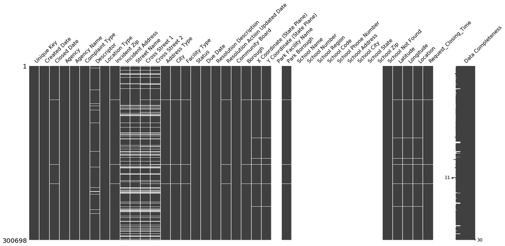

```python
msno.matrix(df_new,labels=df_new.all)
```

```python
# Again we need to drop some new columns!!
list_to_drop2=['Park Facility Name','School Name','School Number','School Region','School Code','School Phone Number','School Address','School City','School State','School Zip']
df_new=df_new.drop(list_to_drop2,axis=1)
```

```python
df_new.shape
```

```
(300698, 30)
```

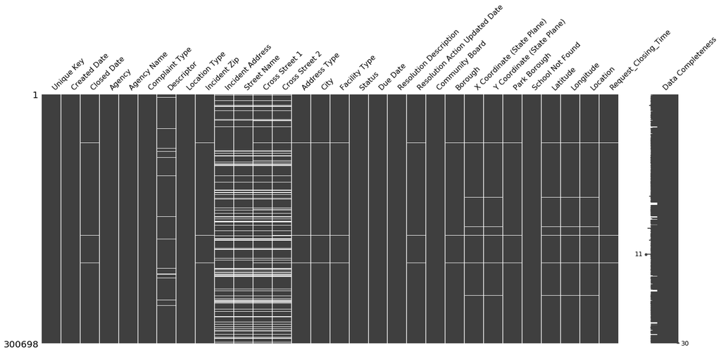

```python
msno.matrix(df_new,labels=df_new.all)
```

```python
df_new.isna().sum()
```

```
Unique Key                            0
Created Date                          0
Closed Date                        2164
Agency                                0
Agency Name                           0
Complaint Type                        0
Descriptor                         5914
Location Type                       131
Incident Zip                       2615
Incident Address                  44410
Street Name                       44410
Cross Street 1                    49279
Cross Street 2                    49779
Address Type                       2815
City                               2614
Facility Type                      2171
Status                                0
Due Date                              3
Resolution Description                0
Resolution Action Updated Date     2187
Community Board                       0
Borough                            2574
X Coordinate (State Plane)         3540
Y Coordinate (State Plane)         3540
Park Borough                       2574
School Not Found                      0
Latitude                           3540
Longitude                          3540
Location                           3540
Request_Closing_Time               2164
dtype: int64
```

```python
df_new
```

|  | Unique Key | Created Date | Closed Date | Agency | Agency Name | Complaint Type | Descriptor | Location Type | Incident Zip | Incident Address | ... | Community Board | Borough | X Coordinate (State Plane) | Y Coordinate (State Plane) | Park Borough | School Not Found | Latitude | Longitude | Location | Request_Closing_Time |
| --- | --- | --- | --- | --- | --- | --- | --- | --- | --- | --- | --- | --- | --- | --- | --- | --- | --- | --- | --- | --- | --- |
| 0 | 32310363 | 2015-12-31 23:59:45 | 2016-01-01 00:55:00 | NYPD | New York City Police Department | Noise - Street/Sidewalk | Loud Music/Party | Street/Sidewalk | 10034.0 | 71 VERMILYEA AVENUE | ... | 12 MANHATTAN | MANHATTAN | 1005409.0 | 254678.0 | MANHATTAN | N | 40.865682 | -73.923501 | (40.86568153633767, -73.92350095571744) | 0 days 00:55:15 |
| 1 | 32309934 | 2015-12-31 23:59:44 | 2016-01-01 01:26:00 | NYPD | New York City Police Department | Blocked Driveway | No Access | Street/Sidewalk | 11105.0 | 27-07 23 AVENUE | ... | 01 QUEENS | QUEENS | 1007766.0 | 221986.0 | QUEENS | N | 40.775945 | -73.915094 | (40.775945312321085, -73.91509393898605) | 0 days 01:26:16 |
| 2 | 32309159 | 2015-12-31 23:59:29 | 2016-01-01 04:51:00 | NYPD | New York City Police Department | Blocked Driveway | No Access | Street/Sidewalk | 10458.0 | 2897 VALENTINE AVENUE | ... | 07 BRONX | BRONX | 1015081.0 | 256380.0 | BRONX | N | 40.870325 | -73.888525 | (40.870324522111424, -73.88852464418646) | 0 days 04:51:31 |
| 3 | 32305098 | 2015-12-31 23:57:46 | 2016-01-01 07:43:00 | NYPD | New York City Police Department | Illegal Parking | Commercial Overnight Parking | Street/Sidewalk | 10461.0 | 2940 BAISLEY AVENUE | ... | 10 BRONX | BRONX | 1031740.0 | 243899.0 | BRONX | N | 40.835994 | -73.828379 | (40.83599404683083, -73.82837939584206) | 0 days 07:45:14 |
| 4 | 32306529 | 2015-12-31 23:56:58 | 2016-01-01 03:24:00 | NYPD | New York City Police Department | Illegal Parking | Blocked Sidewalk | Street/Sidewalk | 11373.0 | 87-14 57 ROAD | ... | 04 QUEENS | QUEENS | 1019123.0 | 206375.0 | QUEENS | N | 40.733060 | -73.874170 | (40.733059618956815, -73.87416975810375) | 0 days 03:27:02 |
| 5 | 32306554 | 2015-12-31 23:56:30 | 2016-01-01 01:50:00 | NYPD | New York City Police Department | Illegal Parking | Posted Parking Sign Violation | Street/Sidewalk | 11215.0 | 260 21 STREET | ... | 07 BROOKLYN | BROOKLYN | 986312.0 | 180032.0 | BROOKLYN | N | 40.660823 | -73.992568 | (40.66082272389114, -73.99256786342693) | 0 days 01:53:30 |
| 6 | 32306559 | 2015-12-31 23:55:32 | 2016-01-01 01:53:00 | NYPD | New York City Police Department | Illegal Parking | Blocked Hydrant | Street/Sidewalk | 10032.0 | 524 WEST 169 STREET | ... | 12 MANHATTAN | MANHATTAN | 1001578.0 | 245627.0 | MANHATTAN | N | 40.840848 | -73.937375 | (40.840847591440415, -73.9373750864581) | 0 days 01:57:28 |
| 7 | 32307009 | 2015-12-31 23:54:05 | 2016-01-01 01:42:00 | NYPD | New York City Police Department | Blocked Driveway | No Access | Street/Sidewalk | 10457.0 | 501 EAST 171 STREET | ... | 03 BRONX | BRONX | 1011117.0 | 244417.0 | BRONX | N | 40.837503 | -73.902905 | (40.83750262540012, -73.90290517326568) | 0 days 01:47:55 |
| 8 | 32308581 | 2015-12-31 23:53:58 | 2016-01-01 08:27:00 | NYPD | New York City Police Department | Illegal Parking | Posted Parking Sign Violation | Street/Sidewalk | 11415.0 | 83-44 LEFFERTS BOULEVARD | ... | 09 QUEENS | QUEENS | 1030662.0 | 196163.0 | QUEENS | N | 40.704977 | -73.832605 | (40.704977164399935, -73.8326047502584) | 0 days 08:33:02 |
| 9 | 32308391 | 2015-12-31 23:53:58 | 2016-01-01 01:17:00 | NYPD | New York City Police Department | Blocked Driveway | No Access | Street/Sidewalk | 11219.0 | 1408 66 STREET | ... | 11 BROOKLYN | BROOKLYN | 984378.0 | 166541.0 | BROOKLYN | N | 40.623793 | -73.999539 | (40.623793065806524, -73.99953890121567) | 0 days 01:23:02 |
| 10 | 32305071 | 2015-12-31 23:52:58 | 2016-01-01 07:41:00 | NYPD | New York City Police Department | Blocked Driveway | No Access | Street/Sidewalk | 11372.0 | 34-06 73 STREET | ... | 03 QUEENS | QUEENS | 1013795.0 | 213487.0 | QUEENS | N | 40.752600 | -73.893363 | (40.752599671969676, -73.8933632141368) | 0 days 07:48:02 |
| 11 | 32306260 | 2015-12-31 23:50:57 | 2016-01-01 10:58:00 | NYPD | New York City Police Department | Blocked Driveway | No Access | Street/Sidewalk | 10453.0 | 1770 UNDERCLIFF AVENUE | ... | 05 BRONX | BRONX | 1006383.0 | 249532.0 | BRONX | N | 40.851555 | -73.919997 | (40.85155492779258, -73.91999651358469) | 0 days 11:07:03 |
| 12 | 32306612 | 2015-12-31 23:48:03 | 2016-01-01 02:17:00 | NYPD | New York City Police Department | Noise - Street/Sidewalk | Loud Music/Party | Street/Sidewalk | 10461.0 | 1701 PILGRIM AVENUE | ... | 10 BRONX | BRONX | 1030293.0 | 247376.0 | BRONX | N | 40.845545 | -73.833585 | (40.845545043640215, -73.83358471831198) | 0 days 02:28:57 |
| 13 | 32305074 | 2015-12-31 23:47:58 | 2016-01-01 08:18:00 | NYPD | New York City Police Department | Illegal Parking | Posted Parking Sign Violation | Street/Sidewalk | 11208.0 | 38 COX PLACE | ... | 05 BROOKLYN | BROOKLYN | 1019054.0 | 189780.0 | BROOKLYN | N | 40.687511 | -73.874505 | (40.68751060232221, -73.87450451131276) | 0 days 08:30:02 |
| 14 | 32309424 | 2015-12-31 23:47:37 | 2016-01-01 10:17:00 | NYPD | New York City Police Department | Derelict Vehicle | With License Plate | Street/Sidewalk | 11379.0 | 62-13 62 AVENUE | ... | 05 QUEENS | QUEENS | 1012143.0 | 199456.0 | QUEENS | N | 40.714093 | -73.899384 | (40.71409341858147, -73.89938394187791) | 0 days 10:29:23 |
| 15 | 32309853 | 2015-12-31 23:47:30 | 2016-01-01 15:20:00 | NYPD | New York City Police Department | Blocked Driveway | Partial Access | Street/Sidewalk | 11374.0 | 61-34 AUSTIN STREET | ... | 06 QUEENS | QUEENS | 1020165.0 | 205145.0 | QUEENS | N | 40.729679 | -73.870417 | (40.72967940444622, -73.87041654016662) | 0 days 15:32:30 |
| 16 | 32305538 | 2015-12-31 23:47:02 | 2016-01-01 04:39:00 | NYPD | New York City Police Department | Blocked Driveway | No Access | Street/Sidewalk | 11412.0 | 192-05 LINDEN BOULEVARD | ... | 12 QUEENS | QUEENS | 1051009.0 | 191672.0 | QUEENS | N | 40.692520 | -73.759264 | (40.69252034680599, -73.75926357603389) | 0 days 04:51:58 |
| 17 | 32310273 | 2015-12-31 23:44:52 | 2016-01-01 00:36:00 | NYPD | New York City Police Department | Noise - Commercial | Loud Music/Party | Club/Bar/Restaurant | 11217.0 | 622 DEGRAW STREET | ... | 06 BROOKLYN | BROOKLYN | 988846.0 | 186711.0 | BROOKLYN | N | 40.679154 | -73.983430 | (40.679154133157326, -73.98342992763081) | 0 days 00:51:08 |
| 18 | 32306617 | 2015-12-31 23:40:59 | 2016-01-01 02:37:00 | NYPD | New York City Police Department | Noise - Commercial | Loud Music/Party | Club/Bar/Restaurant | 11234.0 | 2192 FLATBUSH AVENUE | ... | 18 BROOKLYN | BROOKLYN | 1003628.0 | 163910.0 | BROOKLYN | N | 40.616550 | -73.930202 | (40.61655032892211, -73.93020153359745) | 0 days 02:56:01 |
| 19 | 32308195 | 2015-12-31 23:40:55 | 2016-01-01 00:28:00 | NYPD | New York City Police Department | Noise - Street/Sidewalk | Loud Music/Party | Street/Sidewalk | 10026.0 | 264 WEST 118 STREET | ... | 10 MANHATTAN | MANHATTAN | 997164.0 | 232661.0 | MANHATTAN | N | 40.805267 | -73.953353 | (40.80526715877265, -73.9533526205901) | 0 days 00:47:05 |
| 20 | 32310127 | 2015-12-31 23:40:43 | 2016-01-01 04:12:00 | NYPD | New York City Police Department | Illegal Parking | Unauthorized Bus Layover | Street/Sidewalk | 10456.0 | 1417 WEBSTER AVENUE | ... | 04 BRONX | BRONX | 1009955.0 | 244133.0 | BRONX | N | 40.836727 | -73.907106 | (40.83672658684552, -73.90710561784778) | 0 days 04:31:17 |
| 21 | 32307994 | 2015-12-31 23:38:51 | 2016-01-01 09:11:00 | NYPD | New York City Police Department | Illegal Parking | Posted Parking Sign Violation | Street/Sidewalk | 11379.0 | 78-42 METROPOLITAN AVENUE | ... | 05 QUEENS | QUEENS | 1019142.0 | 199139.0 | QUEENS | N | 40.713198 | -73.874139 | (40.713198496024376, -73.87413871579652) | 0 days 09:32:09 |
| 22 | 32307233 | 2015-12-31 23:34:18 | 2016-01-01 00:50:00 | NYPD | New York City Police Department | Noise - Commercial | Loud Music/Party | Store/Commercial | 11234.0 | 3622 QUENTIN ROAD | ... | 18 BROOKLYN | BROOKLYN | 1001861.0 | 163265.0 | BROOKLYN | N | 40.614784 | -73.936568 | (40.61478362623815, -73.93656784825214) | 0 days 01:15:42 |
| 23 | 32308765 | 2015-12-31 23:32:46 | 2016-01-01 00:25:00 | NYPD | New York City Police Department | Illegal Parking | Double Parked Blocking Vehicle | Street/Sidewalk | 10030.0 | 133 WEST 134 STREET | ... | 10 MANHATTAN | MANHATTAN | 1000121.0 | 235845.0 | MANHATTAN | N | 40.814002 | -73.942664 | (40.814001537165495, -73.94266395083876) | 0 days 00:52:14 |
| 24 | 32308423 | 2015-12-31 23:31:40 | 2016-01-03 16:22:00 | NYPD | New York City Police Department | Blocked Driveway | No Access | Street/Sidewalk | 10467.0 | 3025 WALLACE AVENUE | ... | 12 BRONX | BRONX | 1021775.0 | 256294.0 | BRONX | N | 40.870063 | -73.864322 | (40.87006255915965, -73.86432172842636) | 2 days 16:50:20 |
| 25 | 32308426 | 2015-12-31 23:30:28 | 2016-01-01 02:47:00 | NYPD | New York City Police Department | Blocked Driveway | No Access | Street/Sidewalk | 11432.0 | 175-18 90 AVENUE | ... | 12 QUEENS | QUEENS | 1043508.0 | 197958.0 | QUEENS | N | 40.709827 | -73.786257 | (40.70982729683097, -73.78625714739626) | 0 days 03:16:32 |
| 26 | 32305916 | 2015-12-31 23:26:41 | 2015-12-31 23:53:31 | NYPD | New York City Police Department | Noise - House of Worship | Loud Music/Party | House of Worship | 10031.0 | 452 WEST 147 STREET | ... | 09 MANHATTAN | MANHATTAN | 999288.0 | 240253.0 | MANHATTAN | N | 40.826102 | -73.945663 | (40.826101709196, -73.94566339279595) | 0 days 00:26:50 |
| 27 | 32308379 | 2015-12-31 23:26:35 | 2016-01-01 05:07:00 | NYPD | New York City Police Department | Blocked Driveway | No Access | Street/Sidewalk | 11419.0 | 103-28 118 STREET | ... | 10 QUEENS | QUEENS | 1032618.0 | 189660.0 | QUEENS | N | 40.687117 | -73.825597 | (40.68711749970851, -73.8255967145633) | 0 days 05:40:25 |
| 28 | 32309402 | 2015-12-31 23:25:56 | 2016-01-01 01:12:00 | NYPD | New York City Police Department | Illegal Parking | Posted Parking Sign Violation | Street/Sidewalk | 10024.0 | 131 WEST 86 STREET | ... | 07 MANHATTAN | MANHATTAN | 991671.0 | 225978.0 | MANHATTAN | N | 40.786930 | -73.973202 | (40.78693045941381, -73.9732015755585) | 0 days 01:46:04 |
| 29 | 32308850 | 2015-12-31 23:25:01 | 2016-01-01 01:55:00 | NYPD | New York City Police Department | Noise - Commercial | Loud Music/Party | Club/Bar/Restaurant | 11201.0 | 216 DUFFIELD STREET | ... | 02 BROOKLYN | BROOKLYN | 988582.0 | 191245.0 | BROOKLYN | N | 40.691599 | -73.984379 | (40.691599059545375, -73.98437881826075) | 0 days 02:29:59 |
| ... | ... | ... | ... | ... | ... | ... | ... | ... | ... | ... | ... | ... | ... | ... | ... | ... | ... | ... | ... | ... | ... |
| 300668 | 30282107 | 2015-03-29 01:03:20 | 2015-03-29 03:40:19 | NYPD | New York City Police Department | Noise - Commercial | Loud Music/Party | Club/Bar/Restaurant | 11216.0 | 305 HALSEY STREET | ... | 03 BROOKLYN | BROOKLYN | 1000792.0 | 188083.0 | BROOKLYN | N | 40.682906 | -73.940357 | (40.68290569745191, -73.94035735919954) | 0 days 02:36:59 |
| 300669 | 30283741 | 2015-03-29 01:02:05 | 2015-03-29 05:26:38 | NYPD | New York City Police Department | Noise - Street/Sidewalk | Loud Music/Party | Street/Sidewalk | 10031.0 | NaN | ... | 09 MANHATTAN | MANHATTAN | 997984.0 | 238556.0 | MANHATTAN | N | 40.821446 | -73.950379 | (40.82144605015569, -73.95037859121894) | 0 days 04:24:33 |
| 300670 | 30284125 | 2015-03-29 01:01:25 | 2015-03-29 09:26:52 | NYPD | New York City Police Department | Illegal Parking | Blocked Hydrant | Street/Sidewalk | 11354.0 | 33-16 143 STREET | ... | 07 QUEENS | QUEENS | 1032388.0 | 219080.0 | QUEENS | N | 40.767869 | -73.826216 | (40.767869319511156, -73.82621558171721) | 0 days 08:25:27 |
| 300671 | 30283901 | 2015-03-29 00:58:08 | 2015-03-29 04:44:02 | NYPD | New York City Police Department | Illegal Parking | Blocked Hydrant | Street/Sidewalk | 10019.0 | 446 WEST 49 STREET | ... | 04 MANHATTAN | MANHATTAN | 986808.0 | 217413.0 | MANHATTAN | N | 40.763425 | -73.990766 | (40.76342452850363, -73.99076591082245) | 0 days 03:45:54 |
| 300672 | 30282374 | 2015-03-29 00:57:27 | 2015-03-29 16:39:53 | NYPD | New York City Police Department | Blocked Driveway | No Access | Street/Sidewalk | 11208.0 | 326 MCKINLEY AVENUE | ... | 05 BROOKLYN | BROOKLYN | 1021994.0 | 187437.0 | BROOKLYN | N | 40.681068 | -73.863917 | (40.68106756068015, -73.8639166657132) | 0 days 15:42:26 |
| 300673 | 30280817 | 2015-03-29 00:57:25 | 2015-03-29 02:25:31 | NYPD | New York City Police Department | Noise - Commercial | Loud Music/Party | Club/Bar/Restaurant | 11203.0 | 196 EAST 51 STREET | ... | 17 BROOKLYN | BROOKLYN | 1003678.0 | 178766.0 | BROOKLYN | N | 40.657327 | -73.929979 | (40.65732675940293, -73.92997866259482) | 0 days 01:28:06 |
| 300674 | 30283364 | 2015-03-29 00:57:19 | 2015-03-29 03:17:59 | NYPD | New York City Police Department | Noise - Street/Sidewalk | Loud Music/Party | Street/Sidewalk | 10025.0 | 220 WEST 107 STREET | ... | 07 MANHATTAN | MANHATTAN | 993678.0 | 231254.0 | MANHATTAN | N | 40.801410 | -73.965947 | (40.80140973782622, -73.96594656979163) | 0 days 02:20:40 |
| 300675 | 30280353 | 2015-03-29 00:56:22 | 2015-03-29 01:57:52 | NYPD | New York City Police Department | Noise - Street/Sidewalk | Loud Music/Party | Street/Sidewalk | 10031.0 | 501 WEST 139 STREET | ... | 09 MANHATTAN | MANHATTAN | 997914.0 | 238598.0 | MANHATTAN | N | 40.821561 | -73.950631 | (40.82156143682672, -73.95063141802162) | 0 days 01:01:30 |
| 300676 | 30280974 | 2015-03-29 00:55:56 | 2015-03-29 08:08:27 | NYPD | New York City Police Department | Noise - Commercial | Loud Music/Party | Store/Commercial | 11377.0 | 50 STREET | ... | 02 QUEENS | QUEENS | 1007833.0 | 210049.0 | QUEENS | N | 40.743181 | -73.914894 | (40.74318114209432, -73.91489390486979) | 0 days 07:12:31 |
| 300677 | 30280622 | 2015-03-29 00:55:33 | 2015-03-29 07:12:39 | NYPD | New York City Police Department | Noise - Commercial | Loud Music/Party | Club/Bar/Restaurant | 11237.0 | 302 IRVING AVENUE | ... | 04 BROOKLYN | BROOKLYN | 1008008.0 | 193944.0 | BROOKLYN | N | 40.698976 | -73.914319 | (40.698976356744375, -73.91431921502723) | 0 days 06:17:06 |
| 300678 | 30282979 | 2015-03-29 00:50:12 | 2015-03-29 07:06:29 | NYPD | New York City Police Department | Noise - Vehicle | Car/Truck Music | Street/Sidewalk | 11206.0 | 29 LOCUST STREET | ... | 04 BROOKLYN | BROOKLYN | 1001584.0 | 194069.0 | BROOKLYN | N | 40.699334 | -73.937486 | (40.699334367421585, -73.93748637968389) | 0 days 06:16:17 |
| 300679 | 30281254 | 2015-03-29 00:49:51 | 2015-03-29 02:02:21 | NYPD | New York City Police Department | Blocked Driveway | No Access | Street/Sidewalk | 11385.0 | 1912 GROVE STREET | ... | 05 QUEENS | QUEENS | 1009895.0 | 196678.0 | QUEENS | N | 40.706475 | -73.907504 | (40.70647527382003, -73.90750353701854) | 0 days 01:12:30 |
| 300680 | 30281090 | 2015-03-29 00:49:27 | 2015-03-29 04:25:53 | NYPD | New York City Police Department | Noise - Vehicle | Car/Truck Music | Street/Sidewalk | 10028.0 | 420 EAST 86 STREET | ... | 08 MANHATTAN | MANHATTAN | 998453.0 | 222214.0 | MANHATTAN | N | 40.776591 | -73.948719 | (40.776590982604596, -73.94871864443712) | 0 days 03:36:26 |
| 300681 | 30283933 | 2015-03-29 00:48:23 | 2015-03-29 03:42:33 | NYPD | New York City Police Department | Noise - Street/Sidewalk | Loud Music/Party | Street/Sidewalk | 11238.0 | 799 DEAN STREET | ... | 08 BROOKLYN | BROOKLYN | 994414.0 | 186743.0 | BROOKLYN | N | 40.679237 | -73.963355 | (40.679237323783724, -73.96335543308066) | 0 days 02:54:10 |
| 300682 | 30283186 | 2015-03-29 00:46:26 | 2015-03-29 07:12:20 | NYPD | New York City Police Department | Noise - Commercial | Loud Music/Party | Club/Bar/Restaurant | 11249.0 | 98A SOUTH 4 STREET | ... | 01 BROOKLYN | BROOKLYN | 994230.0 | 198783.0 | BROOKLYN | N | 40.712285 | -73.964001 | (40.712284534374824, -73.96400097454304) | 0 days 06:25:54 |
| 300683 | 30284534 | 2015-03-29 00:44:36 | 2015-03-29 03:40:20 | NYPD | New York City Police Department | Noise - Street/Sidewalk | Loud Talking | Street/Sidewalk | 11238.0 | 801 DEAN STREET | ... | 08 BROOKLYN | BROOKLYN | 994427.0 | 186739.0 | BROOKLYN | N | 40.679226 | -73.963309 | (40.67922632975442, -73.96330856984594) | 0 days 02:55:44 |
| 300684 | 30281081 | 2015-03-29 00:43:20 | 2015-03-29 01:10:55 | NYPD | New York City Police Department | Noise - Commercial | Loud Music/Party | Store/Commercial | 10002.0 | 9 STANTON STREET | ... | 03 MANHATTAN | MANHATTAN | 986347.0 | 202547.0 | MANHATTAN | N | 40.722621 | -73.992435 | (40.722621191327846, -73.99243470311887) | 0 days 00:27:35 |
| 300685 | 30280506 | 2015-03-29 00:43:16 | 2015-03-29 04:25:50 | NYPD | New York City Police Department | Noise - Vehicle | Car/Truck Music | Street/Sidewalk | 10028.0 | 415 EAST 86 STREET | ... | 08 MANHATTAN | MANHATTAN | 998429.0 | 222234.0 | MANHATTAN | N | 40.776646 | -73.948805 | (40.77664591586459, -73.94880525662063) | 0 days 03:42:34 |
| 300686 | 30281145 | 2015-03-29 00:43:06 | 2015-03-29 00:57:23 | NYPD | New York City Police Department | Noise - Commercial | Loud Music/Party | Store/Commercial | 10014.0 | 185 CHRISTOPHER STREET | ... | 02 MANHATTAN | MANHATTAN | 981565.0 | 206141.0 | MANHATTAN | N | 40.732486 | -74.009688 | (40.73248568650513, -74.00968804444769) | 0 days 00:14:17 |
| 300687 | 30282599 | 2015-03-29 00:42:48 | 2015-03-29 02:57:41 | NYPD | New York City Police Department | Blocked Driveway | No Access | Street/Sidewalk | 11385.0 | 77-03 79 PLACE | ... | 05 QUEENS | QUEENS | 1019948.0 | 196646.0 | QUEENS | N | 40.706353 | -73.871245 | (40.70635259429073, -73.8712445609601) | 0 days 02:14:53 |
| 300688 | 30280732 | 2015-03-29 00:37:15 | 2015-03-29 01:02:39 | NYPD | New York City Police Department | Noise - Commercial | Loud Music/Party | Club/Bar/Restaurant | 10014.0 | 22 9 AVENUE | ... | 02 MANHATTAN | MANHATTAN | 982648.0 | 209010.0 | MANHATTAN | N | 40.740361 | -74.005781 | (40.74036064515079, -74.00578103597579) | 0 days 00:25:24 |
| 300689 | 30283432 | 2015-03-29 00:35:28 | 2015-03-29 04:14:27 | NYPD | New York City Police Department | Noise - Street/Sidewalk | Loud Music/Party | Street/Sidewalk | 11233.0 | 120 CHAUNCEY STREET | ... | 03 BROOKLYN | BROOKLYN | 1003827.0 | 187172.0 | BROOKLYN | N | 40.680399 | -73.929417 | (40.6803990181202, -73.92941723335176) | 0 days 03:38:59 |
| 300690 | 30280538 | 2015-03-29 00:35:23 | 2015-03-29 08:41:24 | NYPD | New York City Police Department | Illegal Parking | Commercial Overnight Parking | Street/Sidewalk | 10466.0 | NaN | ... | 12 BRONX | BRONX | 1028258.0 | 267359.0 | BRONX | N | 40.900403 | -73.840809 | (40.90040252667784, -73.84080863767632) | 0 days 08:06:01 |
| 300691 | 30279999 | 2015-03-29 00:35:04 | 2015-03-29 02:52:28 | NYPD | New York City Police Department | Noise - Commercial | Loud Music/Party | Store/Commercial | 10034.0 | 97 SHERMAN AVENUE | ... | 12 MANHATTAN | MANHATTAN | 1004896.0 | 253994.0 | MANHATTAN | N | 40.863805 | -73.925358 | (40.863805379005, -73.92535778152539) | 0 days 02:17:24 |
| 300692 | 30281370 | 2015-03-29 00:34:32 | 2015-03-29 01:13:01 | NYPD | New York City Police Department | Noise - Commercial | Loud Music/Party | Store/Commercial | 10002.0 | 81 HESTER STREET | ... | 03 MANHATTAN | MANHATTAN | 986640.0 | 200154.0 | MANHATTAN | N | 40.716053 | -73.991378 | (40.71605290789855, -73.99137850370803) | 0 days 00:38:29 |
| 300693 | 30281872 | 2015-03-29 00:33:41 | NaT | NYPD | New York City Police Department | Noise - Commercial | Loud Music/Party | Club/Bar/Restaurant | NaN | CRESCENT AVENUE | ... | 0 Unspecified | NaN | NaN | NaN | NaN | N | NaN | NaN | NaN | NaT |
| 300694 | 30281230 | 2015-03-29 00:33:28 | 2015-03-29 02:33:59 | NYPD | New York City Police Department | Blocked Driveway | Partial Access | Street/Sidewalk | 11418.0 | 100-17 87 AVENUE | ... | 09 QUEENS | QUEENS | 1026931.0 | 192185.0 | QUEENS | N | 40.694077 | -73.846087 | (40.69407728322387, -73.8460866160573) | 0 days 02:00:31 |
| 300695 | 30283424 | 2015-03-29 00:33:03 | 2015-03-29 03:40:20 | NYPD | New York City Police Department | Noise - Commercial | Loud Music/Party | Club/Bar/Restaurant | 11206.0 | 162 THROOP AVENUE | ... | 03 BROOKLYN | BROOKLYN | 999713.0 | 194161.0 | BROOKLYN | N | 40.699590 | -73.944234 | (40.69959035300927, -73.94423377144169) | 0 days 03:07:17 |
| 300696 | 30280004 | 2015-03-29 00:33:02 | 2015-03-29 04:38:35 | NYPD | New York City Police Department | Noise - Commercial | Loud Music/Party | Club/Bar/Restaurant | 10461.0 | 3151 EAST TREMONT AVENUE | ... | 10 BRONX | BRONX | 1030021.0 | 244520.0 | BRONX | N | 40.837708 | -73.834587 | (40.8377075854206, -73.83458731019586) | 0 days 04:05:33 |
| 300697 | 30281825 | 2015-03-29 00:33:01 | 2015-03-29 04:41:50 | NYPD | New York City Police Department | Noise - Commercial | Loud Music/Party | Store/Commercial | 10036.0 | 251 WEST 48 STREET | ... | 05 MANHATTAN | MANHATTAN | 988150.0 | 216378.0 | MANHATTAN | N | 40.760583 | -73.985922 | (40.76058322950115, -73.98592204392392) | 0 days 04:08:49 |

300698 rows × 30 columns

```python
#Since there are relatively few missing values left and they're mostly string values we can use dropna to drop those records
# we also still have alot of records left that we can use !
df_new=df_new.dropna(axis=0)
```

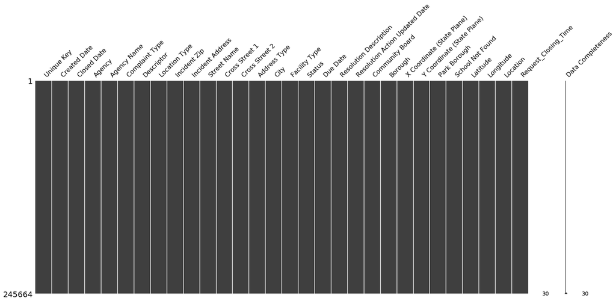

```python
msno.matrix(df_new,labels=df_new.all)
# making sure we dont have null values left!
```

```python
#Now we can use groupby the type of complaints to see which are the most placed complaint
```

```python
df_new.groupby(['Complaint Type','Descriptor']).size()
```

```
Complaint Type            Descriptor
Animal Abuse              Chained                             424
                          In Car                              150
                          Neglected                          3339
                          No Shelter                          314
                          Other (complaint details)          1597
                          Tortured                            749
Blocked Driveway          No Access                         55656
                          Partial Access                    19635
Derelict Vehicle          With License Plate                14477
Disorderly Youth          Nuisance/Truant                      16
                          Playing in Unsuitable Place         169
Drinking                  After Hours - Licensed Est           68
                          In Public                           707
                          Underage - Licensed Est             232
Graffiti                  Police Report Not Requested          12
                          Police Report Requested              83
Illegal Parking           Blocked Hydrant                   14505
                          Blocked Sidewalk                   9132
                          Commercial Overnight Parking       9541
                          Detached Trailer                    314
                          Double Parked Blocking Traffic     4182
                          Double Parked Blocking Vehicle     2973
                          Overnight Commercial Storage       1257
                          Posted Parking Sign Violation     17231
                          Unauthorized Bus Layover           1010
Noise - Commercial        Banging/Pounding                   3556
                          Car/Truck Horn                      895
                          Car/Truck Music                     749
                          Loud Music/Party                  23169
                          Loud Talking                       3565
                          Loud Television                      86
Noise - House of Worship  Banging/Pounding                    232
                          Loud Music/Party                    357
                          Loud Talking                        106
                          Loud Television                       1
Noise - Park              Loud Music/Party                    938
                          Loud Talking                        332
Noise - Street/Sidewalk   Loud Music/Party                  24365
                          Loud Talking                      13668
Noise - Vehicle           Car/Truck Horn                     1428
                          Car/Truck Music                    7693
                          Engine Idling                      3001
Posting Advertisement     Building                             58
                          Vehicle                             563
Traffic                   Chronic Speeding                    102
                          Chronic Stoplight Violation          24
                          Congestion/Gridlock                 521
                          Drag Racing                          72
                          Truck Route Violation               199
Vending                   In Prohibited Area                 1298
                          Unlicensed                          913
dtype: int64
```

```python
#This is the most frequent complaint made
df_new.groupby(['Complaint Type','Descriptor']).size().argmax()
```

```
('Blocked Driveway', 'No Access')
```

```python
#This the least frequent complaint made!!
df_new.groupby(['Complaint Type','Descriptor']).size().argmin()
```

```
('Noise - House of Worship', 'Loud Television')
```

```python
df_city=df_new.groupby('City')
```

```python
df_city['Complaint Type'].agg(['count','max','min'])
```

| City | count | max | min |
| --- | --- | --- | --- |
| ARVERNE | 173 | Vending | Animal Abuse |
| ASTORIA | 5517 | Vending | Animal Abuse |
| Astoria | 715 | Noise - Street/Sidewalk | Blocked Driveway |
| BAYSIDE | 975 | Traffic | Animal Abuse |
| BELLEROSE | 296 | Traffic | Animal Abuse |
| BREEZY POINT | 28 | Noise - Vehicle | Animal Abuse |
| BRONX | 34518 | Vending | Animal Abuse |
| BROOKLYN | 84197 | Vending | Animal Abuse |
| CAMBRIA HEIGHTS | 386 | Traffic | Animal Abuse |
| COLLEGE POINT | 1090 | Vending | Animal Abuse |
| CORONA | 3918 | Vending | Animal Abuse |
| EAST ELMHURST | 2451 | Vending | Animal Abuse |
| ELMHURST | 2388 | Vending | Animal Abuse |
| East Elmhurst | 14 | Illegal Parking | Derelict Vehicle |
| FAR ROCKAWAY | 915 | Vending | Animal Abuse |
| FLORAL PARK | 130 | Noise - Vehicle | Animal Abuse |
| FLUSHING | 5170 | Vending | Animal Abuse |
| FOREST HILLS | 1320 | Vending | Animal Abuse |
| FRESH MEADOWS | 1616 | Traffic | Animal Abuse |
| GLEN OAKS | 226 | Vending | Animal Abuse |
| HOLLIS | 896 | Traffic | Animal Abuse |
| HOWARD BEACH | 729 | Vending | Animal Abuse |
| Howard Beach | 1 | Blocked Driveway | Blocked Driveway |
| JACKSON HEIGHTS | 1441 | Vending | Animal Abuse |
| JAMAICA | 5706 | Vending | Animal Abuse |
| KEW GARDENS | 696 | Vending | Animal Abuse |
| LITTLE NECK | 477 | Traffic | Animal Abuse |
| LONG ISLAND CITY | 1929 | Vending | Animal Abuse |
| Long Island City | 134 | Noise - Street/Sidewalk | Blocked Driveway |
| MASPETH | 1999 | Vending | Animal Abuse |
| MIDDLE VILLAGE | 1455 | Traffic | Animal Abuse |
| NEW HYDE PARK | 79 | Noise - Vehicle | Animal Abuse |
| NEW YORK | 48429 | Vending | Animal Abuse |
| OAKLAND GARDENS | 379 | Traffic | Animal Abuse |
| OZONE PARK | 2389 | Vending | Animal Abuse |
| QUEENS VILLAGE | 1463 | Traffic | Animal Abuse |
| REGO PARK | 1255 | Vending | Animal Abuse |
| RICHMOND HILL | 1715 | Vending | Animal Abuse |
| RIDGEWOOD | 4373 | Vending | Animal Abuse |
| ROCKAWAY PARK | 595 | Vending | Animal Abuse |
| ROSEDALE | 643 | Vending | Animal Abuse |
| SAINT ALBANS | 633 | Vending | Animal Abuse |
| SOUTH OZONE PARK | 1886 | Vending | Animal Abuse |
| SOUTH RICHMOND HILL | 2544 | Vending | Animal Abuse |
| SPRINGFIELD GARDENS | 736 | Vending | Animal Abuse |
| STATEN ISLAND | 10283 | Vending | Animal Abuse |
| SUNNYSIDE | 590 | Vending | Animal Abuse |
| WHITESTONE | 852 | Traffic | Animal Abuse |
| WOODHAVEN | 2221 | Vending | Animal Abuse |
| WOODSIDE | 2973 | Vending | Animal Abuse |
| Woodside | 120 | Noise - Street/Sidewalk | Blocked Driveway |

```python
#We can also drop the Created and closed date for the complaint since we already calculated the Request closing time!
#df_new=df_new.drop(['Created Date','Closed Date'],axis=1)
df_new
```

|  | Unique Key | Created Date | Closed Date | Agency | Agency Name | Complaint Type | Descriptor | Location Type | Incident Zip | Incident Address | ... | Community Board | Borough | X Coordinate (State Plane) | Y Coordinate (State Plane) | Park Borough | School Not Found | Latitude | Longitude | Location | Request_Closing_Time |
| --- | --- | --- | --- | --- | --- | --- | --- | --- | --- | --- | --- | --- | --- | --- | --- | --- | --- | --- | --- | --- | --- |
| 0 | 32310363 | 2015-12-31 23:59:45 | 2016-01-01 00:55:00 | NYPD | New York City Police Department | Noise - Street/Sidewalk | Loud Music/Party | Street/Sidewalk | 10034.0 | 71 VERMILYEA AVENUE | ... | 12 MANHATTAN | MANHATTAN | 1005409.0 | 254678.0 | MANHATTAN | N | 40.865682 | -73.923501 | (40.86568153633767, -73.92350095571744) | 0 days 00:55:15 |
| 1 | 32309934 | 2015-12-31 23:59:44 | 2016-01-01 01:26:00 | NYPD | New York City Police Department | Blocked Driveway | No Access | Street/Sidewalk | 11105.0 | 27-07 23 AVENUE | ... | 01 QUEENS | QUEENS | 1007766.0 | 221986.0 | QUEENS | N | 40.775945 | -73.915094 | (40.775945312321085, -73.91509393898605) | 0 days 01:26:16 |
| 2 | 32309159 | 2015-12-31 23:59:29 | 2016-01-01 04:51:00 | NYPD | New York City Police Department | Blocked Driveway | No Access | Street/Sidewalk | 10458.0 | 2897 VALENTINE AVENUE | ... | 07 BRONX | BRONX | 1015081.0 | 256380.0 | BRONX | N | 40.870325 | -73.888525 | (40.870324522111424, -73.88852464418646) | 0 days 04:51:31 |
| 3 | 32305098 | 2015-12-31 23:57:46 | 2016-01-01 07:43:00 | NYPD | New York City Police Department | Illegal Parking | Commercial Overnight Parking | Street/Sidewalk | 10461.0 | 2940 BAISLEY AVENUE | ... | 10 BRONX | BRONX | 1031740.0 | 243899.0 | BRONX | N | 40.835994 | -73.828379 | (40.83599404683083, -73.82837939584206) | 0 days 07:45:14 |
| 4 | 32306529 | 2015-12-31 23:56:58 | 2016-01-01 03:24:00 | NYPD | New York City Police Department | Illegal Parking | Blocked Sidewalk | Street/Sidewalk | 11373.0 | 87-14 57 ROAD | ... | 04 QUEENS | QUEENS | 1019123.0 | 206375.0 | QUEENS | N | 40.733060 | -73.874170 | (40.733059618956815, -73.87416975810375) | 0 days 03:27:02 |
| 5 | 32306554 | 2015-12-31 23:56:30 | 2016-01-01 01:50:00 | NYPD | New York City Police Department | Illegal Parking | Posted Parking Sign Violation | Street/Sidewalk | 11215.0 | 260 21 STREET | ... | 07 BROOKLYN | BROOKLYN | 986312.0 | 180032.0 | BROOKLYN | N | 40.660823 | -73.992568 | (40.66082272389114, -73.99256786342693) | 0 days 01:53:30 |
| 6 | 32306559 | 2015-12-31 23:55:32 | 2016-01-01 01:53:00 | NYPD | New York City Police Department | Illegal Parking | Blocked Hydrant | Street/Sidewalk | 10032.0 | 524 WEST 169 STREET | ... | 12 MANHATTAN | MANHATTAN | 1001578.0 | 245627.0 | MANHATTAN | N | 40.840848 | -73.937375 | (40.840847591440415, -73.9373750864581) | 0 days 01:57:28 |
| 7 | 32307009 | 2015-12-31 23:54:05 | 2016-01-01 01:42:00 | NYPD | New York City Police Department | Blocked Driveway | No Access | Street/Sidewalk | 10457.0 | 501 EAST 171 STREET | ... | 03 BRONX | BRONX | 1011117.0 | 244417.0 | BRONX | N | 40.837503 | -73.902905 | (40.83750262540012, -73.90290517326568) | 0 days 01:47:55 |
| 8 | 32308581 | 2015-12-31 23:53:58 | 2016-01-01 08:27:00 | NYPD | New York City Police Department | Illegal Parking | Posted Parking Sign Violation | Street/Sidewalk | 11415.0 | 83-44 LEFFERTS BOULEVARD | ... | 09 QUEENS | QUEENS | 1030662.0 | 196163.0 | QUEENS | N | 40.704977 | -73.832605 | (40.704977164399935, -73.8326047502584) | 0 days 08:33:02 |
| 9 | 32308391 | 2015-12-31 23:53:58 | 2016-01-01 01:17:00 | NYPD | New York City Police Department | Blocked Driveway | No Access | Street/Sidewalk | 11219.0 | 1408 66 STREET | ... | 11 BROOKLYN | BROOKLYN | 984378.0 | 166541.0 | BROOKLYN | N | 40.623793 | -73.999539 | (40.623793065806524, -73.99953890121567) | 0 days 01:23:02 |
| 10 | 32305071 | 2015-12-31 23:52:58 | 2016-01-01 07:41:00 | NYPD | New York City Police Department | Blocked Driveway | No Access | Street/Sidewalk | 11372.0 | 34-06 73 STREET | ... | 03 QUEENS | QUEENS | 1013795.0 | 213487.0 | QUEENS | N | 40.752600 | -73.893363 | (40.752599671969676, -73.8933632141368) | 0 days 07:48:02 |
| 11 | 32306260 | 2015-12-31 23:50:57 | 2016-01-01 10:58:00 | NYPD | New York City Police Department | Blocked Driveway | No Access | Street/Sidewalk | 10453.0 | 1770 UNDERCLIFF AVENUE | ... | 05 BRONX | BRONX | 1006383.0 | 249532.0 | BRONX | N | 40.851555 | -73.919997 | (40.85155492779258, -73.91999651358469) | 0 days 11:07:03 |
| 12 | 32306612 | 2015-12-31 23:48:03 | 2016-01-01 02:17:00 | NYPD | New York City Police Department | Noise - Street/Sidewalk | Loud Music/Party | Street/Sidewalk | 10461.0 | 1701 PILGRIM AVENUE | ... | 10 BRONX | BRONX | 1030293.0 | 247376.0 | BRONX | N | 40.845545 | -73.833585 | (40.845545043640215, -73.83358471831198) | 0 days 02:28:57 |
| 13 | 32305074 | 2015-12-31 23:47:58 | 2016-01-01 08:18:00 | NYPD | New York City Police Department | Illegal Parking | Posted Parking Sign Violation | Street/Sidewalk | 11208.0 | 38 COX PLACE | ... | 05 BROOKLYN | BROOKLYN | 1019054.0 | 189780.0 | BROOKLYN | N | 40.687511 | -73.874505 | (40.68751060232221, -73.87450451131276) | 0 days 08:30:02 |
| 14 | 32309424 | 2015-12-31 23:47:37 | 2016-01-01 10:17:00 | NYPD | New York City Police Department | Derelict Vehicle | With License Plate | Street/Sidewalk | 11379.0 | 62-13 62 AVENUE | ... | 05 QUEENS | QUEENS | 1012143.0 | 199456.0 | QUEENS | N | 40.714093 | -73.899384 | (40.71409341858147, -73.89938394187791) | 0 days 10:29:23 |
| 15 | 32309853 | 2015-12-31 23:47:30 | 2016-01-01 15:20:00 | NYPD | New York City Police Department | Blocked Driveway | Partial Access | Street/Sidewalk | 11374.0 | 61-34 AUSTIN STREET | ... | 06 QUEENS | QUEENS | 1020165.0 | 205145.0 | QUEENS | N | 40.729679 | -73.870417 | (40.72967940444622, -73.87041654016662) | 0 days 15:32:30 |
| 16 | 32305538 | 2015-12-31 23:47:02 | 2016-01-01 04:39:00 | NYPD | New York City Police Department | Blocked Driveway | No Access | Street/Sidewalk | 11412.0 | 192-05 LINDEN BOULEVARD | ... | 12 QUEENS | QUEENS | 1051009.0 | 191672.0 | QUEENS | N | 40.692520 | -73.759264 | (40.69252034680599, -73.75926357603389) | 0 days 04:51:58 |
| 17 | 32310273 | 2015-12-31 23:44:52 | 2016-01-01 00:36:00 | NYPD | New York City Police Department | Noise - Commercial | Loud Music/Party | Club/Bar/Restaurant | 11217.0 | 622 DEGRAW STREET | ... | 06 BROOKLYN | BROOKLYN | 988846.0 | 186711.0 | BROOKLYN | N | 40.679154 | -73.983430 | (40.679154133157326, -73.98342992763081) | 0 days 00:51:08 |
| 18 | 32306617 | 2015-12-31 23:40:59 | 2016-01-01 02:37:00 | NYPD | New York City Police Department | Noise - Commercial | Loud Music/Party | Club/Bar/Restaurant | 11234.0 | 2192 FLATBUSH AVENUE | ... | 18 BROOKLYN | BROOKLYN | 1003628.0 | 163910.0 | BROOKLYN | N | 40.616550 | -73.930202 | (40.61655032892211, -73.93020153359745) | 0 days 02:56:01 |
| 19 | 32308195 | 2015-12-31 23:40:55 | 2016-01-01 00:28:00 | NYPD | New York City Police Department | Noise - Street/Sidewalk | Loud Music/Party | Street/Sidewalk | 10026.0 | 264 WEST 118 STREET | ... | 10 MANHATTAN | MANHATTAN | 997164.0 | 232661.0 | MANHATTAN | N | 40.805267 | -73.953353 | (40.80526715877265, -73.9533526205901) | 0 days 00:47:05 |
| 20 | 32310127 | 2015-12-31 23:40:43 | 2016-01-01 04:12:00 | NYPD | New York City Police Department | Illegal Parking | Unauthorized Bus Layover | Street/Sidewalk | 10456.0 | 1417 WEBSTER AVENUE | ... | 04 BRONX | BRONX | 1009955.0 | 244133.0 | BRONX | N | 40.836727 | -73.907106 | (40.83672658684552, -73.90710561784778) | 0 days 04:31:17 |
| 21 | 32307994 | 2015-12-31 23:38:51 | 2016-01-01 09:11:00 | NYPD | New York City Police Department | Illegal Parking | Posted Parking Sign Violation | Street/Sidewalk | 11379.0 | 78-42 METROPOLITAN AVENUE | ... | 05 QUEENS | QUEENS | 1019142.0 | 199139.0 | QUEENS | N | 40.713198 | -73.874139 | (40.713198496024376, -73.87413871579652) | 0 days 09:32:09 |
| 22 | 32307233 | 2015-12-31 23:34:18 | 2016-01-01 00:50:00 | NYPD | New York City Police Department | Noise - Commercial | Loud Music/Party | Store/Commercial | 11234.0 | 3622 QUENTIN ROAD | ... | 18 BROOKLYN | BROOKLYN | 1001861.0 | 163265.0 | BROOKLYN | N | 40.614784 | -73.936568 | (40.61478362623815, -73.93656784825214) | 0 days 01:15:42 |
| 23 | 32308765 | 2015-12-31 23:32:46 | 2016-01-01 00:25:00 | NYPD | New York City Police Department | Illegal Parking | Double Parked Blocking Vehicle | Street/Sidewalk | 10030.0 | 133 WEST 134 STREET | ... | 10 MANHATTAN | MANHATTAN | 1000121.0 | 235845.0 | MANHATTAN | N | 40.814002 | -73.942664 | (40.814001537165495, -73.94266395083876) | 0 days 00:52:14 |
| 24 | 32308423 | 2015-12-31 23:31:40 | 2016-01-03 16:22:00 | NYPD | New York City Police Department | Blocked Driveway | No Access | Street/Sidewalk | 10467.0 | 3025 WALLACE AVENUE | ... | 12 BRONX | BRONX | 1021775.0 | 256294.0 | BRONX | N | 40.870063 | -73.864322 | (40.87006255915965, -73.86432172842636) | 2 days 16:50:20 |
| 25 | 32308426 | 2015-12-31 23:30:28 | 2016-01-01 02:47:00 | NYPD | New York City Police Department | Blocked Driveway | No Access | Street/Sidewalk | 11432.0 | 175-18 90 AVENUE | ... | 12 QUEENS | QUEENS | 1043508.0 | 197958.0 | QUEENS | N | 40.709827 | -73.786257 | (40.70982729683097, -73.78625714739626) | 0 days 03:16:32 |
| 26 | 32305916 | 2015-12-31 23:26:41 | 2015-12-31 23:53:31 | NYPD | New York City Police Department | Noise - House of Worship | Loud Music/Party | House of Worship | 10031.0 | 452 WEST 147 STREET | ... | 09 MANHATTAN | MANHATTAN | 999288.0 | 240253.0 | MANHATTAN | N | 40.826102 | -73.945663 | (40.826101709196, -73.94566339279595) | 0 days 00:26:50 |
| 27 | 32308379 | 2015-12-31 23:26:35 | 2016-01-01 05:07:00 | NYPD | New York City Police Department | Blocked Driveway | No Access | Street/Sidewalk | 11419.0 | 103-28 118 STREET | ... | 10 QUEENS | QUEENS | 1032618.0 | 189660.0 | QUEENS | N | 40.687117 | -73.825597 | (40.68711749970851, -73.8255967145633) | 0 days 05:40:25 |
| 28 | 32309402 | 2015-12-31 23:25:56 | 2016-01-01 01:12:00 | NYPD | New York City Police Department | Illegal Parking | Posted Parking Sign Violation | Street/Sidewalk | 10024.0 | 131 WEST 86 STREET | ... | 07 MANHATTAN | MANHATTAN | 991671.0 | 225978.0 | MANHATTAN | N | 40.786930 | -73.973202 | (40.78693045941381, -73.9732015755585) | 0 days 01:46:04 |
| 29 | 32308850 | 2015-12-31 23:25:01 | 2016-01-01 01:55:00 | NYPD | New York City Police Department | Noise - Commercial | Loud Music/Party | Club/Bar/Restaurant | 11201.0 | 216 DUFFIELD STREET | ... | 02 BROOKLYN | BROOKLYN | 988582.0 | 191245.0 | BROOKLYN | N | 40.691599 | -73.984379 | (40.691599059545375, -73.98437881826075) | 0 days 02:29:59 |
| ... | ... | ... | ... | ... | ... | ... | ... | ... | ... | ... | ... | ... | ... | ... | ... | ... | ... | ... | ... | ... | ... |
| 300663 | 30283185 | 2015-03-29 01:07:45 | 2015-03-29 03:30:38 | NYPD | New York City Police Department | Noise - Commercial | Loud Music/Party | Store/Commercial | 11238.0 | 789 DEAN STREET | ... | 08 BROOKLYN | BROOKLYN | 994345.0 | 186761.0 | BROOKLYN | N | 40.679287 | -73.963604 | (40.67928680865997, -73.96360417380941) | 0 days 02:22:53 |
| 300664 | 30279480 | 2015-03-29 01:07:03 | 2015-03-29 02:45:46 | NYPD | New York City Police Department | Noise - Commercial | Loud Music/Party | Club/Bar/Restaurant | 10009.0 | 62 AVENUE C | ... | 03 MANHATTAN | MANHATTAN | 989817.0 | 202545.0 | MANHATTAN | N | 40.722614 | -73.979916 | (40.72261419868281, -73.97991606884368) | 0 days 01:38:43 |
| 300665 | 30281355 | 2015-03-29 01:05:14 | 2015-03-29 02:18:01 | NYPD | New York City Police Department | Blocked Driveway | Partial Access | Street/Sidewalk | 11204.0 | 1982 59 STREET | ... | 12 BROOKLYN | BROOKLYN | 989005.0 | 165272.0 | BROOKLYN | N | 40.620309 | -73.982872 | (40.62030865063931, -73.982871794702) | 0 days 01:12:47 |
| 300668 | 30282107 | 2015-03-29 01:03:20 | 2015-03-29 03:40:19 | NYPD | New York City Police Department | Noise - Commercial | Loud Music/Party | Club/Bar/Restaurant | 11216.0 | 305 HALSEY STREET | ... | 03 BROOKLYN | BROOKLYN | 1000792.0 | 188083.0 | BROOKLYN | N | 40.682906 | -73.940357 | (40.68290569745191, -73.94035735919954) | 0 days 02:36:59 |
| 300670 | 30284125 | 2015-03-29 01:01:25 | 2015-03-29 09:26:52 | NYPD | New York City Police Department | Illegal Parking | Blocked Hydrant | Street/Sidewalk | 11354.0 | 33-16 143 STREET | ... | 07 QUEENS | QUEENS | 1032388.0 | 219080.0 | QUEENS | N | 40.767869 | -73.826216 | (40.767869319511156, -73.82621558171721) | 0 days 08:25:27 |
| 300671 | 30283901 | 2015-03-29 00:58:08 | 2015-03-29 04:44:02 | NYPD | New York City Police Department | Illegal Parking | Blocked Hydrant | Street/Sidewalk | 10019.0 | 446 WEST 49 STREET | ... | 04 MANHATTAN | MANHATTAN | 986808.0 | 217413.0 | MANHATTAN | N | 40.763425 | -73.990766 | (40.76342452850363, -73.99076591082245) | 0 days 03:45:54 |
| 300672 | 30282374 | 2015-03-29 00:57:27 | 2015-03-29 16:39:53 | NYPD | New York City Police Department | Blocked Driveway | No Access | Street/Sidewalk | 11208.0 | 326 MCKINLEY AVENUE | ... | 05 BROOKLYN | BROOKLYN | 1021994.0 | 187437.0 | BROOKLYN | N | 40.681068 | -73.863917 | (40.68106756068015, -73.8639166657132) | 0 days 15:42:26 |
| 300673 | 30280817 | 2015-03-29 00:57:25 | 2015-03-29 02:25:31 | NYPD | New York City Police Department | Noise - Commercial | Loud Music/Party | Club/Bar/Restaurant | 11203.0 | 196 EAST 51 STREET | ... | 17 BROOKLYN | BROOKLYN | 1003678.0 | 178766.0 | BROOKLYN | N | 40.657327 | -73.929979 | (40.65732675940293, -73.92997866259482) | 0 days 01:28:06 |
| 300674 | 30283364 | 2015-03-29 00:57:19 | 2015-03-29 03:17:59 | NYPD | New York City Police Department | Noise - Street/Sidewalk | Loud Music/Party | Street/Sidewalk | 10025.0 | 220 WEST 107 STREET | ... | 07 MANHATTAN | MANHATTAN | 993678.0 | 231254.0 | MANHATTAN | N | 40.801410 | -73.965947 | (40.80140973782622, -73.96594656979163) | 0 days 02:20:40 |
| 300675 | 30280353 | 2015-03-29 00:56:22 | 2015-03-29 01:57:52 | NYPD | New York City Police Department | Noise - Street/Sidewalk | Loud Music/Party | Street/Sidewalk | 10031.0 | 501 WEST 139 STREET | ... | 09 MANHATTAN | MANHATTAN | 997914.0 | 238598.0 | MANHATTAN | N | 40.821561 | -73.950631 | (40.82156143682672, -73.95063141802162) | 0 days 01:01:30 |
| 300676 | 30280974 | 2015-03-29 00:55:56 | 2015-03-29 08:08:27 | NYPD | New York City Police Department | Noise - Commercial | Loud Music/Party | Store/Commercial | 11377.0 | 50 STREET | ... | 02 QUEENS | QUEENS | 1007833.0 | 210049.0 | QUEENS | N | 40.743181 | -73.914894 | (40.74318114209432, -73.91489390486979) | 0 days 07:12:31 |
| 300677 | 30280622 | 2015-03-29 00:55:33 | 2015-03-29 07:12:39 | NYPD | New York City Police Department | Noise - Commercial | Loud Music/Party | Club/Bar/Restaurant | 11237.0 | 302 IRVING AVENUE | ... | 04 BROOKLYN | BROOKLYN | 1008008.0 | 193944.0 | BROOKLYN | N | 40.698976 | -73.914319 | (40.698976356744375, -73.91431921502723) | 0 days 06:17:06 |
| 300678 | 30282979 | 2015-03-29 00:50:12 | 2015-03-29 07:06:29 | NYPD | New York City Police Department | Noise - Vehicle | Car/Truck Music | Street/Sidewalk | 11206.0 | 29 LOCUST STREET | ... | 04 BROOKLYN | BROOKLYN | 1001584.0 | 194069.0 | BROOKLYN | N | 40.699334 | -73.937486 | (40.699334367421585, -73.93748637968389) | 0 days 06:16:17 |
| 300679 | 30281254 | 2015-03-29 00:49:51 | 2015-03-29 02:02:21 | NYPD | New York City Police Department | Blocked Driveway | No Access | Street/Sidewalk | 11385.0 | 1912 GROVE STREET | ... | 05 QUEENS | QUEENS | 1009895.0 | 196678.0 | QUEENS | N | 40.706475 | -73.907504 | (40.70647527382003, -73.90750353701854) | 0 days 01:12:30 |
| 300680 | 30281090 | 2015-03-29 00:49:27 | 2015-03-29 04:25:53 | NYPD | New York City Police Department | Noise - Vehicle | Car/Truck Music | Street/Sidewalk | 10028.0 | 420 EAST 86 STREET | ... | 08 MANHATTAN | MANHATTAN | 998453.0 | 222214.0 | MANHATTAN | N | 40.776591 | -73.948719 | (40.776590982604596, -73.94871864443712) | 0 days 03:36:26 |
| 300681 | 30283933 | 2015-03-29 00:48:23 | 2015-03-29 03:42:33 | NYPD | New York City Police Department | Noise - Street/Sidewalk | Loud Music/Party | Street/Sidewalk | 11238.0 | 799 DEAN STREET | ... | 08 BROOKLYN | BROOKLYN | 994414.0 | 186743.0 | BROOKLYN | N | 40.679237 | -73.963355 | (40.679237323783724, -73.96335543308066) | 0 days 02:54:10 |
| 300682 | 30283186 | 2015-03-29 00:46:26 | 2015-03-29 07:12:20 | NYPD | New York City Police Department | Noise - Commercial | Loud Music/Party | Club/Bar/Restaurant | 11249.0 | 98A SOUTH 4 STREET | ... | 01 BROOKLYN | BROOKLYN | 994230.0 | 198783.0 | BROOKLYN | N | 40.712285 | -73.964001 | (40.712284534374824, -73.96400097454304) | 0 days 06:25:54 |
| 300683 | 30284534 | 2015-03-29 00:44:36 | 2015-03-29 03:40:20 | NYPD | New York City Police Department | Noise - Street/Sidewalk | Loud Talking | Street/Sidewalk | 11238.0 | 801 DEAN STREET | ... | 08 BROOKLYN | BROOKLYN | 994427.0 | 186739.0 | BROOKLYN | N | 40.679226 | -73.963309 | (40.67922632975442, -73.96330856984594) | 0 days 02:55:44 |
| 300684 | 30281081 | 2015-03-29 00:43:20 | 2015-03-29 01:10:55 | NYPD | New York City Police Department | Noise - Commercial | Loud Music/Party | Store/Commercial | 10002.0 | 9 STANTON STREET | ... | 03 MANHATTAN | MANHATTAN | 986347.0 | 202547.0 | MANHATTAN | N | 40.722621 | -73.992435 | (40.722621191327846, -73.99243470311887) | 0 days 00:27:35 |
| 300685 | 30280506 | 2015-03-29 00:43:16 | 2015-03-29 04:25:50 | NYPD | New York City Police Department | Noise - Vehicle | Car/Truck Music | Street/Sidewalk | 10028.0 | 415 EAST 86 STREET | ... | 08 MANHATTAN | MANHATTAN | 998429.0 | 222234.0 | MANHATTAN | N | 40.776646 | -73.948805 | (40.77664591586459, -73.94880525662063) | 0 days 03:42:34 |
| 300686 | 30281145 | 2015-03-29 00:43:06 | 2015-03-29 00:57:23 | NYPD | New York City Police Department | Noise - Commercial | Loud Music/Party | Store/Commercial | 10014.0 | 185 CHRISTOPHER STREET | ... | 02 MANHATTAN | MANHATTAN | 981565.0 | 206141.0 | MANHATTAN | N | 40.732486 | -74.009688 | (40.73248568650513, -74.00968804444769) | 0 days 00:14:17 |
| 300687 | 30282599 | 2015-03-29 00:42:48 | 2015-03-29 02:57:41 | NYPD | New York City Police Department | Blocked Driveway | No Access | Street/Sidewalk | 11385.0 | 77-03 79 PLACE | ... | 05 QUEENS | QUEENS | 1019948.0 | 196646.0 | QUEENS | N | 40.706353 | -73.871245 | (40.70635259429073, -73.8712445609601) | 0 days 02:14:53 |
| 300688 | 30280732 | 2015-03-29 00:37:15 | 2015-03-29 01:02:39 | NYPD | New York City Police Department | Noise - Commercial | Loud Music/Party | Club/Bar/Restaurant | 10014.0 | 22 9 AVENUE | ... | 02 MANHATTAN | MANHATTAN | 982648.0 | 209010.0 | MANHATTAN | N | 40.740361 | -74.005781 | (40.74036064515079, -74.00578103597579) | 0 days 00:25:24 |
| 300689 | 30283432 | 2015-03-29 00:35:28 | 2015-03-29 04:14:27 | NYPD | New York City Police Department | Noise - Street/Sidewalk | Loud Music/Party | Street/Sidewalk | 11233.0 | 120 CHAUNCEY STREET | ... | 03 BROOKLYN | BROOKLYN | 1003827.0 | 187172.0 | BROOKLYN | N | 40.680399 | -73.929417 | (40.6803990181202, -73.92941723335176) | 0 days 03:38:59 |
| 300691 | 30279999 | 2015-03-29 00:35:04 | 2015-03-29 02:52:28 | NYPD | New York City Police Department | Noise - Commercial | Loud Music/Party | Store/Commercial | 10034.0 | 97 SHERMAN AVENUE | ... | 12 MANHATTAN | MANHATTAN | 1004896.0 | 253994.0 | MANHATTAN | N | 40.863805 | -73.925358 | (40.863805379005, -73.92535778152539) | 0 days 02:17:24 |
| 300692 | 30281370 | 2015-03-29 00:34:32 | 2015-03-29 01:13:01 | NYPD | New York City Police Department | Noise - Commercial | Loud Music/Party | Store/Commercial | 10002.0 | 81 HESTER STREET | ... | 03 MANHATTAN | MANHATTAN | 986640.0 | 200154.0 | MANHATTAN | N | 40.716053 | -73.991378 | (40.71605290789855, -73.99137850370803) | 0 days 00:38:29 |
| 300694 | 30281230 | 2015-03-29 00:33:28 | 2015-03-29 02:33:59 | NYPD | New York City Police Department | Blocked Driveway | Partial Access | Street/Sidewalk | 11418.0 | 100-17 87 AVENUE | ... | 09 QUEENS | QUEENS | 1026931.0 | 192185.0 | QUEENS | N | 40.694077 | -73.846087 | (40.69407728322387, -73.8460866160573) | 0 days 02:00:31 |
| 300695 | 30283424 | 2015-03-29 00:33:03 | 2015-03-29 03:40:20 | NYPD | New York City Police Department | Noise - Commercial | Loud Music/Party | Club/Bar/Restaurant | 11206.0 | 162 THROOP AVENUE | ... | 03 BROOKLYN | BROOKLYN | 999713.0 | 194161.0 | BROOKLYN | N | 40.699590 | -73.944234 | (40.69959035300927, -73.94423377144169) | 0 days 03:07:17 |
| 300696 | 30280004 | 2015-03-29 00:33:02 | 2015-03-29 04:38:35 | NYPD | New York City Police Department | Noise - Commercial | Loud Music/Party | Club/Bar/Restaurant | 10461.0 | 3151 EAST TREMONT AVENUE | ... | 10 BRONX | BRONX | 1030021.0 | 244520.0 | BRONX | N | 40.837708 | -73.834587 | (40.8377075854206, -73.83458731019586) | 0 days 04:05:33 |
| 300697 | 30281825 | 2015-03-29 00:33:01 | 2015-03-29 04:41:50 | NYPD | New York City Police Department | Noise - Commercial | Loud Music/Party | Store/Commercial | 10036.0 | 251 WEST 48 STREET | ... | 05 MANHATTAN | MANHATTAN | 988150.0 | 216378.0 | MANHATTAN | N | 40.760583 | -73.985922 | (40.76058322950115, -73.98592204392392) | 0 days 04:08:49 |

245664 rows × 30 columns

```python
#We should drop School Not Found attribute
df_new=df_new.drop('School Not Found',axis=1)
```

```python
df_new=df_new.drop(['Unique Key','Agency','Agency Name'],axis=1)
df_new
```

|  | Created Date | Closed Date | Complaint Type | Descriptor | Location Type | Incident Zip | Incident Address | Street Name | Cross Street 1 | Cross Street 2 | ... | Resolution Action Updated Date | Community Board | Borough | X Coordinate (State Plane) | Y Coordinate (State Plane) | Park Borough | Latitude | Longitude | Location | Request_Closing_Time |
| --- | --- | --- | --- | --- | --- | --- | --- | --- | --- | --- | --- | --- | --- | --- | --- | --- | --- | --- | --- | --- | --- |
| 0 | 2015-12-31 23:59:45 | 2016-01-01 00:55:00 | Noise - Street/Sidewalk | Loud Music/Party | Street/Sidewalk | 10034.0 | 71 VERMILYEA AVENUE | VERMILYEA AVENUE | ACADEMY STREET | WEST 204 STREET | ... | 01-01-16 0:55 | 12 MANHATTAN | MANHATTAN | 1005409.0 | 254678.0 | MANHATTAN | 40.865682 | -73.923501 | (40.86568153633767, -73.92350095571744) | 0 days 00:55:15 |
| 1 | 2015-12-31 23:59:44 | 2016-01-01 01:26:00 | Blocked Driveway | No Access | Street/Sidewalk | 11105.0 | 27-07 23 AVENUE | 23 AVENUE | 27 STREET | 28 STREET | ... | 01-01-16 1:26 | 01 QUEENS | QUEENS | 1007766.0 | 221986.0 | QUEENS | 40.775945 | -73.915094 | (40.775945312321085, -73.91509393898605) | 0 days 01:26:16 |
| 2 | 2015-12-31 23:59:29 | 2016-01-01 04:51:00 | Blocked Driveway | No Access | Street/Sidewalk | 10458.0 | 2897 VALENTINE AVENUE | VALENTINE AVENUE | EAST 198 STREET | EAST 199 STREET | ... | 01-01-16 4:51 | 07 BRONX | BRONX | 1015081.0 | 256380.0 | BRONX | 40.870325 | -73.888525 | (40.870324522111424, -73.88852464418646) | 0 days 04:51:31 |
| 3 | 2015-12-31 23:57:46 | 2016-01-01 07:43:00 | Illegal Parking | Commercial Overnight Parking | Street/Sidewalk | 10461.0 | 2940 BAISLEY AVENUE | BAISLEY AVENUE | EDISON AVENUE | B STREET | ... | 01-01-16 7:43 | 10 BRONX | BRONX | 1031740.0 | 243899.0 | BRONX | 40.835994 | -73.828379 | (40.83599404683083, -73.82837939584206) | 0 days 07:45:14 |
| 4 | 2015-12-31 23:56:58 | 2016-01-01 03:24:00 | Illegal Parking | Blocked Sidewalk | Street/Sidewalk | 11373.0 | 87-14 57 ROAD | 57 ROAD | SEABURY STREET | HOFFMAN DRIVE | ... | 01-01-16 3:24 | 04 QUEENS | QUEENS | 1019123.0 | 206375.0 | QUEENS | 40.733060 | -73.874170 | (40.733059618956815, -73.87416975810375) | 0 days 03:27:02 |
| 5 | 2015-12-31 23:56:30 | 2016-01-01 01:50:00 | Illegal Parking | Posted Parking Sign Violation | Street/Sidewalk | 11215.0 | 260 21 STREET | 21 STREET | 5 AVENUE | 6 AVENUE | ... | 01-01-16 1:50 | 07 BROOKLYN | BROOKLYN | 986312.0 | 180032.0 | BROOKLYN | 40.660823 | -73.992568 | (40.66082272389114, -73.99256786342693) | 0 days 01:53:30 |
| 6 | 2015-12-31 23:55:32 | 2016-01-01 01:53:00 | Illegal Parking | Blocked Hydrant | Street/Sidewalk | 10032.0 | 524 WEST 169 STREET | WEST 169 STREET | AMSTERDAM AVENUE | AUDUBON AVENUE | ... | 01-01-16 1:53 | 12 MANHATTAN | MANHATTAN | 1001578.0 | 245627.0 | MANHATTAN | 40.840848 | -73.937375 | (40.840847591440415, -73.9373750864581) | 0 days 01:57:28 |
| 7 | 2015-12-31 23:54:05 | 2016-01-01 01:42:00 | Blocked Driveway | No Access | Street/Sidewalk | 10457.0 | 501 EAST 171 STREET | EAST 171 STREET | WASHINGTON AVENUE | 3 AVENUE | ... | 01-01-16 1:42 | 03 BRONX | BRONX | 1011117.0 | 244417.0 | BRONX | 40.837503 | -73.902905 | (40.83750262540012, -73.90290517326568) | 0 days 01:47:55 |
| 8 | 2015-12-31 23:53:58 | 2016-01-01 08:27:00 | Illegal Parking | Posted Parking Sign Violation | Street/Sidewalk | 11415.0 | 83-44 LEFFERTS BOULEVARD | LEFFERTS BOULEVARD | BEND | BEND | ... | 01-01-16 8:27 | 09 QUEENS | QUEENS | 1030662.0 | 196163.0 | QUEENS | 40.704977 | -73.832605 | (40.704977164399935, -73.8326047502584) | 0 days 08:33:02 |
| 9 | 2015-12-31 23:53:58 | 2016-01-01 01:17:00 | Blocked Driveway | No Access | Street/Sidewalk | 11219.0 | 1408 66 STREET | 66 STREET | 14 AVENUE | NEW UTRECHT AVENUE | ... | 01-01-16 1:17 | 11 BROOKLYN | BROOKLYN | 984378.0 | 166541.0 | BROOKLYN | 40.623793 | -73.999539 | (40.623793065806524, -73.99953890121567) | 0 days 01:23:02 |
| 10 | 2015-12-31 23:52:58 | 2016-01-01 07:41:00 | Blocked Driveway | No Access | Street/Sidewalk | 11372.0 | 34-06 73 STREET | 73 STREET | 34 AVENUE | 35 AVENUE | ... | 01-01-16 7:41 | 03 QUEENS | QUEENS | 1013795.0 | 213487.0 | QUEENS | 40.752600 | -73.893363 | (40.752599671969676, -73.8933632141368) | 0 days 07:48:02 |
| 11 | 2015-12-31 23:50:57 | 2016-01-01 10:58:00 | Blocked Driveway | No Access | Street/Sidewalk | 10453.0 | 1770 UNDERCLIFF AVENUE | UNDERCLIFF AVENUE | WEST 176 STREET | SEDGWICK AVENUE | ... | 01-01-16 10:58 | 05 BRONX | BRONX | 1006383.0 | 249532.0 | BRONX | 40.851555 | -73.919997 | (40.85155492779258, -73.91999651358469) | 0 days 11:07:03 |
| 12 | 2015-12-31 23:48:03 | 2016-01-01 02:17:00 | Noise - Street/Sidewalk | Loud Music/Party | Street/Sidewalk | 10461.0 | 1701 PILGRIM AVENUE | PILGRIM AVENUE | ROBERTS AVENUE | WESTCHESTER AVENUE | ... | 01-01-16 2:18 | 10 BRONX | BRONX | 1030293.0 | 247376.0 | BRONX | 40.845545 | -73.833585 | (40.845545043640215, -73.83358471831198) | 0 days 02:28:57 |
| 13 | 2015-12-31 23:47:58 | 2016-01-01 08:18:00 | Illegal Parking | Posted Parking Sign Violation | Street/Sidewalk | 11208.0 | 38 COX PLACE | COX PLACE | CRESCENT STREET | DEAD END | ... | 01-01-16 8:18 | 05 BROOKLYN | BROOKLYN | 1019054.0 | 189780.0 | BROOKLYN | 40.687511 | -73.874505 | (40.68751060232221, -73.87450451131276) | 0 days 08:30:02 |
| 14 | 2015-12-31 23:47:37 | 2016-01-01 10:17:00 | Derelict Vehicle | With License Plate | Street/Sidewalk | 11379.0 | 62-13 62 AVENUE | 62 AVENUE | 62 STREET | 64 STREET | ... | 01-01-16 10:17 | 05 QUEENS | QUEENS | 1012143.0 | 199456.0 | QUEENS | 40.714093 | -73.899384 | (40.71409341858147, -73.89938394187791) | 0 days 10:29:23 |
| 15 | 2015-12-31 23:47:30 | 2016-01-01 15:20:00 | Blocked Driveway | Partial Access | Street/Sidewalk | 11374.0 | 61-34 AUSTIN STREET | AUSTIN STREET | ELIOT AVENUE | 62 AVENUE | ... | 01-01-16 15:20 | 06 QUEENS | QUEENS | 1020165.0 | 205145.0 | QUEENS | 40.729679 | -73.870417 | (40.72967940444622, -73.87041654016662) | 0 days 15:32:30 |
| 16 | 2015-12-31 23:47:02 | 2016-01-01 04:39:00 | Blocked Driveway | No Access | Street/Sidewalk | 11412.0 | 192-05 LINDEN BOULEVARD | LINDEN BOULEVARD | 192 STREET | 193 STREET | ... | 01-01-16 4:39 | 12 QUEENS | QUEENS | 1051009.0 | 191672.0 | QUEENS | 40.692520 | -73.759264 | (40.69252034680599, -73.75926357603389) | 0 days 04:51:58 |
| 17 | 2015-12-31 23:44:52 | 2016-01-01 00:36:00 | Noise - Commercial | Loud Music/Party | Club/Bar/Restaurant | 11217.0 | 622 DEGRAW STREET | DEGRAW STREET | 3 AVENUE | 4 AVENUE | ... | 01-01-16 0:36 | 06 BROOKLYN | BROOKLYN | 988846.0 | 186711.0 | BROOKLYN | 40.679154 | -73.983430 | (40.679154133157326, -73.98342992763081) | 0 days 00:51:08 |
| 18 | 2015-12-31 23:40:59 | 2016-01-01 02:37:00 | Noise - Commercial | Loud Music/Party | Club/Bar/Restaurant | 11234.0 | 2192 FLATBUSH AVENUE | FLATBUSH AVENUE | EAST 46 STREET | AVENUE O | ... | 01-01-16 2:37 | 18 BROOKLYN | BROOKLYN | 1003628.0 | 163910.0 | BROOKLYN | 40.616550 | -73.930202 | (40.61655032892211, -73.93020153359745) | 0 days 02:56:01 |
| 19 | 2015-12-31 23:40:55 | 2016-01-01 00:28:00 | Noise - Street/Sidewalk | Loud Music/Party | Street/Sidewalk | 10026.0 | 264 WEST 118 STREET | WEST 118 STREET | ST NICHOLAS AVENUE | 8 AVENUE | ... | 01-01-16 0:28 | 10 MANHATTAN | MANHATTAN | 997164.0 | 232661.0 | MANHATTAN | 40.805267 | -73.953353 | (40.80526715877265, -73.9533526205901) | 0 days 00:47:05 |
| 20 | 2015-12-31 23:40:43 | 2016-01-01 04:12:00 | Illegal Parking | Unauthorized Bus Layover | Street/Sidewalk | 10456.0 | 1417 WEBSTER AVENUE | WEBSTER AVENUE | EAST 170 STREET | EAST 171 STREET | ... | 01-01-16 4:12 | 04 BRONX | BRONX | 1009955.0 | 244133.0 | BRONX | 40.836727 | -73.907106 | (40.83672658684552, -73.90710561784778) | 0 days 04:31:17 |
| 21 | 2015-12-31 23:38:51 | 2016-01-01 09:11:00 | Illegal Parking | Posted Parking Sign Violation | Street/Sidewalk | 11379.0 | 78-42 METROPOLITAN AVENUE | METROPOLITAN AVENUE | 79 STREET | 79 STREET | ... | 01-01-16 9:11 | 05 QUEENS | QUEENS | 1019142.0 | 199139.0 | QUEENS | 40.713198 | -73.874139 | (40.713198496024376, -73.87413871579652) | 0 days 09:32:09 |
| 22 | 2015-12-31 23:34:18 | 2016-01-01 00:50:00 | Noise - Commercial | Loud Music/Party | Store/Commercial | 11234.0 | 3622 QUENTIN ROAD | QUENTIN ROAD | EAST 36 STREET | EAST 37 STREET | ... | 01-01-16 0:50 | 18 BROOKLYN | BROOKLYN | 1001861.0 | 163265.0 | BROOKLYN | 40.614784 | -73.936568 | (40.61478362623815, -73.93656784825214) | 0 days 01:15:42 |
| 23 | 2015-12-31 23:32:46 | 2016-01-01 00:25:00 | Illegal Parking | Double Parked Blocking Vehicle | Street/Sidewalk | 10030.0 | 133 WEST 134 STREET | WEST 134 STREET | LENOX AVENUE | 7 AVENUE | ... | 01-01-16 0:25 | 10 MANHATTAN | MANHATTAN | 1000121.0 | 235845.0 | MANHATTAN | 40.814002 | -73.942664 | (40.814001537165495, -73.94266395083876) | 0 days 00:52:14 |
| 24 | 2015-12-31 23:31:40 | 2016-01-03 16:22:00 | Blocked Driveway | No Access | Street/Sidewalk | 10467.0 | 3025 WALLACE AVENUE | WALLACE AVENUE | ADEE AVENUE | BURKE AVENUE | ... | 01-03-16 16:22 | 12 BRONX | BRONX | 1021775.0 | 256294.0 | BRONX | 40.870063 | -73.864322 | (40.87006255915965, -73.86432172842636) | 2 days 16:50:20 |
| 25 | 2015-12-31 23:30:28 | 2016-01-01 02:47:00 | Blocked Driveway | No Access | Street/Sidewalk | 11432.0 | 175-18 90 AVENUE | 90 AVENUE | 175 STREET | 176 STREET | ... | 01-01-16 2:47 | 12 QUEENS | QUEENS | 1043508.0 | 197958.0 | QUEENS | 40.709827 | -73.786257 | (40.70982729683097, -73.78625714739626) | 0 days 03:16:32 |
| 26 | 2015-12-31 23:26:41 | 2015-12-31 23:53:31 | Noise - House of Worship | Loud Music/Party | House of Worship | 10031.0 | 452 WEST 147 STREET | WEST 147 STREET | CONVENT AVENUE | AMSTERDAM AVENUE | ... | 12/31/2015 11:53:31 PM | 09 MANHATTAN | MANHATTAN | 999288.0 | 240253.0 | MANHATTAN | 40.826102 | -73.945663 | (40.826101709196, -73.94566339279595) | 0 days 00:26:50 |
| 27 | 2015-12-31 23:26:35 | 2016-01-01 05:07:00 | Blocked Driveway | No Access | Street/Sidewalk | 11419.0 | 103-28 118 STREET | 118 STREET | 103 AVENUE | LIBERTY AVENUE | ... | 01-01-16 5:07 | 10 QUEENS | QUEENS | 1032618.0 | 189660.0 | QUEENS | 40.687117 | -73.825597 | (40.68711749970851, -73.8255967145633) | 0 days 05:40:25 |
| 28 | 2015-12-31 23:25:56 | 2016-01-01 01:12:00 | Illegal Parking | Posted Parking Sign Violation | Street/Sidewalk | 10024.0 | 131 WEST 86 STREET | WEST 86 STREET | COLUMBUS AVENUE | AMSTERDAM AVENUE | ... | 01-01-16 1:12 | 07 MANHATTAN | MANHATTAN | 991671.0 | 225978.0 | MANHATTAN | 40.786930 | -73.973202 | (40.78693045941381, -73.9732015755585) | 0 days 01:46:04 |
| 29 | 2015-12-31 23:25:01 | 2016-01-01 01:55:00 | Noise - Commercial | Loud Music/Party | Club/Bar/Restaurant | 11201.0 | 216 DUFFIELD STREET | DUFFIELD STREET | WILLOUGHBY STREET | FULTON STREET | ... | 01-01-16 1:55 | 02 BROOKLYN | BROOKLYN | 988582.0 | 191245.0 | BROOKLYN | 40.691599 | -73.984379 | (40.691599059545375, -73.98437881826075) | 0 days 02:29:59 |
| ... | ... | ... | ... | ... | ... | ... | ... | ... | ... | ... | ... | ... | ... | ... | ... | ... | ... | ... | ... | ... | ... |
| 300663 | 2015-03-29 01:07:45 | 2015-03-29 03:30:38 | Noise - Commercial | Loud Music/Party | Store/Commercial | 11238.0 | 789 DEAN STREET | DEAN STREET | WASHINGTON AVENUE | GRAND AVENUE | ... | 03/29/2015 03:30:38 AM | 08 BROOKLYN | BROOKLYN | 994345.0 | 186761.0 | BROOKLYN | 40.679287 | -73.963604 | (40.67928680865997, -73.96360417380941) | 0 days 02:22:53 |
| 300664 | 2015-03-29 01:07:03 | 2015-03-29 02:45:46 | Noise - Commercial | Loud Music/Party | Club/Bar/Restaurant | 10009.0 | 62 AVENUE C | AVENUE C | EAST 4 STREET | EAST 5 STREET | ... | 03/29/2015 02:45:46 AM | 03 MANHATTAN | MANHATTAN | 989817.0 | 202545.0 | MANHATTAN | 40.722614 | -73.979916 | (40.72261419868281, -73.97991606884368) | 0 days 01:38:43 |
| 300665 | 2015-03-29 01:05:14 | 2015-03-29 02:18:01 | Blocked Driveway | Partial Access | Street/Sidewalk | 11204.0 | 1982 59 STREET | 59 STREET | 19 AVENUE | 20 AVENUE | ... | 03/29/2015 02:18:01 AM | 12 BROOKLYN | BROOKLYN | 989005.0 | 165272.0 | BROOKLYN | 40.620309 | -73.982872 | (40.62030865063931, -73.982871794702) | 0 days 01:12:47 |
| 300668 | 2015-03-29 01:03:20 | 2015-03-29 03:40:19 | Noise - Commercial | Loud Music/Party | Club/Bar/Restaurant | 11216.0 | 305 HALSEY STREET | HALSEY STREET | THROOP AVENUE | MARCUS GARVEY BOULEVARD | ... | 03/29/2015 03:40:19 AM | 03 BROOKLYN | BROOKLYN | 1000792.0 | 188083.0 | BROOKLYN | 40.682906 | -73.940357 | (40.68290569745191, -73.94035735919954) | 0 days 02:36:59 |
| 300670 | 2015-03-29 01:01:25 | 2015-03-29 09:26:52 | Illegal Parking | Blocked Hydrant | Street/Sidewalk | 11354.0 | 33-16 143 STREET | 143 STREET | 33 AVENUE | DEAD END | ... | 03/29/2015 09:26:52 AM | 07 QUEENS | QUEENS | 1032388.0 | 219080.0 | QUEENS | 40.767869 | -73.826216 | (40.767869319511156, -73.82621558171721) | 0 days 08:25:27 |
| 300671 | 2015-03-29 00:58:08 | 2015-03-29 04:44:02 | Illegal Parking | Blocked Hydrant | Street/Sidewalk | 10019.0 | 446 WEST 49 STREET | WEST 49 STREET | 9 AVENUE | 10 AVENUE | ... | 03/29/2015 04:44:02 AM | 04 MANHATTAN | MANHATTAN | 986808.0 | 217413.0 | MANHATTAN | 40.763425 | -73.990766 | (40.76342452850363, -73.99076591082245) | 0 days 03:45:54 |
| 300672 | 2015-03-29 00:57:27 | 2015-03-29 16:39:53 | Blocked Driveway | No Access | Street/Sidewalk | 11208.0 | 326 MCKINLEY AVENUE | MCKINLEY AVENUE | FORBELL STREET | DREW STREET | ... | 03/29/2015 04:39:53 PM | 05 BROOKLYN | BROOKLYN | 1021994.0 | 187437.0 | BROOKLYN | 40.681068 | -73.863917 | (40.68106756068015, -73.8639166657132) | 0 days 15:42:26 |
| 300673 | 2015-03-29 00:57:25 | 2015-03-29 02:25:31 | Noise - Commercial | Loud Music/Party | Club/Bar/Restaurant | 11203.0 | 196 EAST 51 STREET | EAST 51 STREET | WINTHROP STREET | CLARKSON AVENUE | ... | 03/29/2015 02:25:31 AM | 17 BROOKLYN | BROOKLYN | 1003678.0 | 178766.0 | BROOKLYN | 40.657327 | -73.929979 | (40.65732675940293, -73.92997866259482) | 0 days 01:28:06 |
| 300674 | 2015-03-29 00:57:19 | 2015-03-29 03:17:59 | Noise - Street/Sidewalk | Loud Music/Party | Street/Sidewalk | 10025.0 | 220 WEST 107 STREET | WEST 107 STREET | AMSTERDAM AVENUE | BROADWAY | ... | 03/29/2015 03:17:59 AM | 07 MANHATTAN | MANHATTAN | 993678.0 | 231254.0 | MANHATTAN | 40.801410 | -73.965947 | (40.80140973782622, -73.96594656979163) | 0 days 02:20:40 |
| 300675 | 2015-03-29 00:56:22 | 2015-03-29 01:57:52 | Noise - Street/Sidewalk | Loud Music/Party | Street/Sidewalk | 10031.0 | 501 WEST 139 STREET | WEST 139 STREET | AMSTERDAM AVENUE | HAMILTON PLACE | ... | 03/29/2015 01:57:53 AM | 09 MANHATTAN | MANHATTAN | 997914.0 | 238598.0 | MANHATTAN | 40.821561 | -73.950631 | (40.82156143682672, -73.95063141802162) | 0 days 01:01:30 |
| 300676 | 2015-03-29 00:55:56 | 2015-03-29 08:08:27 | Noise - Commercial | Loud Music/Party | Store/Commercial | 11377.0 | 50 STREET | 50 STREET | ROOSEVELT AVENUE | QUEENS BOULEVARD | ... | 03/29/2015 08:08:27 AM | 02 QUEENS | QUEENS | 1007833.0 | 210049.0 | QUEENS | 40.743181 | -73.914894 | (40.74318114209432, -73.91489390486979) | 0 days 07:12:31 |
| 300677 | 2015-03-29 00:55:33 | 2015-03-29 07:12:39 | Noise - Commercial | Loud Music/Party | Club/Bar/Restaurant | 11237.0 | 302 IRVING AVENUE | IRVING AVENUE | MYRTLE AVENUE | LINDEN STREET | ... | 03/29/2015 07:12:40 AM | 04 BROOKLYN | BROOKLYN | 1008008.0 | 193944.0 | BROOKLYN | 40.698976 | -73.914319 | (40.698976356744375, -73.91431921502723) | 0 days 06:17:06 |
| 300678 | 2015-03-29 00:50:12 | 2015-03-29 07:06:29 | Noise - Vehicle | Car/Truck Music | Street/Sidewalk | 11206.0 | 29 LOCUST STREET | LOCUST STREET | BROADWAY | BEAVER STREET | ... | 03/29/2015 07:06:29 AM | 04 BROOKLYN | BROOKLYN | 1001584.0 | 194069.0 | BROOKLYN | 40.699334 | -73.937486 | (40.699334367421585, -73.93748637968389) | 0 days 06:16:17 |
| 300679 | 2015-03-29 00:49:51 | 2015-03-29 02:02:21 | Blocked Driveway | No Access | Street/Sidewalk | 11385.0 | 1912 GROVE STREET | GROVE STREET | WOODWARD AVENUE | ST JOHNS ROAD | ... | 03/29/2015 02:02:21 AM | 05 QUEENS | QUEENS | 1009895.0 | 196678.0 | QUEENS | 40.706475 | -73.907504 | (40.70647527382003, -73.90750353701854) | 0 days 01:12:30 |
| 300680 | 2015-03-29 00:49:27 | 2015-03-29 04:25:53 | Noise - Vehicle | Car/Truck Music | Street/Sidewalk | 10028.0 | 420 EAST 86 STREET | EAST 86 STREET | 1 AVENUE | YORK AVENUE | ... | 03/29/2015 04:25:53 AM | 08 MANHATTAN | MANHATTAN | 998453.0 | 222214.0 | MANHATTAN | 40.776591 | -73.948719 | (40.776590982604596, -73.94871864443712) | 0 days 03:36:26 |
| 300681 | 2015-03-29 00:48:23 | 2015-03-29 03:42:33 | Noise - Street/Sidewalk | Loud Music/Party | Street/Sidewalk | 11238.0 | 799 DEAN STREET | DEAN STREET | WASHINGTON AVENUE | GRAND AVENUE | ... | 03/29/2015 03:42:33 AM | 08 BROOKLYN | BROOKLYN | 994414.0 | 186743.0 | BROOKLYN | 40.679237 | -73.963355 | (40.679237323783724, -73.96335543308066) | 0 days 02:54:10 |
| 300682 | 2015-03-29 00:46:26 | 2015-03-29 07:12:20 | Noise - Commercial | Loud Music/Party | Club/Bar/Restaurant | 11249.0 | 98A SOUTH 4 STREET | SOUTH 4 STREET | BERRY STREET | BEDFORD AVENUE | ... | 03/29/2015 07:12:20 AM | 01 BROOKLYN | BROOKLYN | 994230.0 | 198783.0 | BROOKLYN | 40.712285 | -73.964001 | (40.712284534374824, -73.96400097454304) | 0 days 06:25:54 |
| 300683 | 2015-03-29 00:44:36 | 2015-03-29 03:40:20 | Noise - Street/Sidewalk | Loud Talking | Street/Sidewalk | 11238.0 | 801 DEAN STREET | DEAN STREET | WASHINGTON AVENUE | GRAND AVENUE | ... | 03/29/2015 03:40:20 AM | 08 BROOKLYN | BROOKLYN | 994427.0 | 186739.0 | BROOKLYN | 40.679226 | -73.963309 | (40.67922632975442, -73.96330856984594) | 0 days 02:55:44 |
| 300684 | 2015-03-29 00:43:20 | 2015-03-29 01:10:55 | Noise - Commercial | Loud Music/Party | Store/Commercial | 10002.0 | 9 STANTON STREET | STANTON STREET | BOWERY | CHRYSTIE STREET | ... | 03/29/2015 01:10:55 AM | 03 MANHATTAN | MANHATTAN | 986347.0 | 202547.0 | MANHATTAN | 40.722621 | -73.992435 | (40.722621191327846, -73.99243470311887) | 0 days 00:27:35 |
| 300685 | 2015-03-29 00:43:16 | 2015-03-29 04:25:50 | Noise - Vehicle | Car/Truck Music | Street/Sidewalk | 10028.0 | 415 EAST 86 STREET | EAST 86 STREET | 1 AVENUE | YORK AVENUE | ... | 03/29/2015 04:25:50 AM | 08 MANHATTAN | MANHATTAN | 998429.0 | 222234.0 | MANHATTAN | 40.776646 | -73.948805 | (40.77664591586459, -73.94880525662063) | 0 days 03:42:34 |
| 300686 | 2015-03-29 00:43:06 | 2015-03-29 00:57:23 | Noise - Commercial | Loud Music/Party | Store/Commercial | 10014.0 | 185 CHRISTOPHER STREET | CHRISTOPHER STREET | WASHINGTON STREET | WEEHAWKEN STREET | ... | 03/29/2015 12:57:23 AM | 02 MANHATTAN | MANHATTAN | 981565.0 | 206141.0 | MANHATTAN | 40.732486 | -74.009688 | (40.73248568650513, -74.00968804444769) | 0 days 00:14:17 |
| 300687 | 2015-03-29 00:42:48 | 2015-03-29 02:57:41 | Blocked Driveway | No Access | Street/Sidewalk | 11385.0 | 77-03 79 PLACE | 79 PLACE | 77 AVENUE | 77 AVENUE | ... | 03/29/2015 02:57:42 AM | 05 QUEENS | QUEENS | 1019948.0 | 196646.0 | QUEENS | 40.706353 | -73.871245 | (40.70635259429073, -73.8712445609601) | 0 days 02:14:53 |
| 300688 | 2015-03-29 00:37:15 | 2015-03-29 01:02:39 | Noise - Commercial | Loud Music/Party | Club/Bar/Restaurant | 10014.0 | 22 9 AVENUE | 9 AVENUE | WEST 13 STREET | WEST 14 STREET | ... | 03/29/2015 01:02:39 AM | 02 MANHATTAN | MANHATTAN | 982648.0 | 209010.0 | MANHATTAN | 40.740361 | -74.005781 | (40.74036064515079, -74.00578103597579) | 0 days 00:25:24 |
| 300689 | 2015-03-29 00:35:28 | 2015-03-29 04:14:27 | Noise - Street/Sidewalk | Loud Music/Party | Street/Sidewalk | 11233.0 | 120 CHAUNCEY STREET | CHAUNCEY STREET | STUYVESANT AVENUE | MALCOLM X BOULEVARD | ... | 03/29/2015 04:14:27 AM | 03 BROOKLYN | BROOKLYN | 1003827.0 | 187172.0 | BROOKLYN | 40.680399 | -73.929417 | (40.6803990181202, -73.92941723335176) | 0 days 03:38:59 |
| 300691 | 2015-03-29 00:35:04 | 2015-03-29 02:52:28 | Noise - Commercial | Loud Music/Party | Store/Commercial | 10034.0 | 97 SHERMAN AVENUE | SHERMAN AVENUE | DYCKMAN STREET | ACADEMY STREET | ... | 03/29/2015 02:52:28 AM | 12 MANHATTAN | MANHATTAN | 1004896.0 | 253994.0 | MANHATTAN | 40.863805 | -73.925358 | (40.863805379005, -73.92535778152539) | 0 days 02:17:24 |
| 300692 | 2015-03-29 00:34:32 | 2015-03-29 01:13:01 | Noise - Commercial | Loud Music/Party | Store/Commercial | 10002.0 | 81 HESTER STREET | HESTER STREET | ORCHARD STREET | ALLEN STREET | ... | 03/29/2015 01:13:01 AM | 03 MANHATTAN | MANHATTAN | 986640.0 | 200154.0 | MANHATTAN | 40.716053 | -73.991378 | (40.71605290789855, -73.99137850370803) | 0 days 00:38:29 |
| 300694 | 2015-03-29 00:33:28 | 2015-03-29 02:33:59 | Blocked Driveway | Partial Access | Street/Sidewalk | 11418.0 | 100-17 87 AVENUE | 87 AVENUE | DEAD END | 102 STREET | ... | 03/29/2015 02:33:59 AM | 09 QUEENS | QUEENS | 1026931.0 | 192185.0 | QUEENS | 40.694077 | -73.846087 | (40.69407728322387, -73.8460866160573) | 0 days 02:00:31 |
| 300695 | 2015-03-29 00:33:03 | 2015-03-29 03:40:20 | Noise - Commercial | Loud Music/Party | Club/Bar/Restaurant | 11206.0 | 162 THROOP AVENUE | THROOP AVENUE | HOPKINS STREET | ELLERY STREET | ... | 03/29/2015 03:40:20 AM | 03 BROOKLYN | BROOKLYN | 999713.0 | 194161.0 | BROOKLYN | 40.699590 | -73.944234 | (40.69959035300927, -73.94423377144169) | 0 days 03:07:17 |
| 300696 | 2015-03-29 00:33:02 | 2015-03-29 04:38:35 | Noise - Commercial | Loud Music/Party | Club/Bar/Restaurant | 10461.0 | 3151 EAST TREMONT AVENUE | EAST TREMONT AVENUE | CODDINGTON AVENUE | LA SALLE AVENUE | ... | 03/29/2015 04:38:35 AM | 10 BRONX | BRONX | 1030021.0 | 244520.0 | BRONX | 40.837708 | -73.834587 | (40.8377075854206, -73.83458731019586) | 0 days 04:05:33 |
| 300697 | 2015-03-29 00:33:01 | 2015-03-29 04:41:50 | Noise - Commercial | Loud Music/Party | Store/Commercial | 10036.0 | 251 WEST 48 STREET | WEST 48 STREET | BROADWAY | 8 AVENUE | ... | 03/29/2015 04:41:50 AM | 05 MANHATTAN | MANHATTAN | 988150.0 | 216378.0 | MANHATTAN | 40.760583 | -73.985922 | (40.76058322950115, -73.98592204392392) | 0 days 04:08:49 |

245664 rows × 26 columns

```python
df_new.groupby(['Incident Zip','Complaint Type']).size()
```

```
Incident Zip  Complaint Type
10000.0       Animal Abuse                  3
              Noise - Street/Sidewalk       1
10001.0       Animal Abuse                 24
              Blocked Driveway             49
              Derelict Vehicle             10
              Drinking                      2
              Graffiti                      1
              Illegal Parking             164
              Noise - Commercial          252
              Noise - Street/Sidewalk     133
              Noise - Vehicle              42
              Posting Advertisement         1
              Traffic                      10
              Vending                      75
10002.0       Animal Abuse                 28
              Blocked Driveway            100
              Derelict Vehicle             14
              Drinking                     13
              Graffiti                      1
              Illegal Parking             678
              Noise - Commercial          899
              Noise - House of Worship      4
              Noise - Park                 33
              Noise - Street/Sidewalk     381
              Noise - Vehicle             134
              Traffic                       3
              Vending                       6
10003.0       Animal Abuse                 64
              Blocked Driveway             83
              Derelict Vehicle             25
                                         ...
11693.0       Animal Abuse                 27
              Blocked Driveway             65
              Derelict Vehicle             21
              Drinking                      1
              Illegal Parking             105
              Noise - Commercial           28
              Noise - Park                  4
              Noise - Street/Sidewalk      25
```

[output cut: 8 more lines]

```
              Noise - Commercial           33
              Noise - Park                  2
              Noise - Street/Sidewalk     163
              Noise - Vehicle              23
              Traffic                       4
              Vending                       2
11697.0       Animal Abuse                  2
              Blocked Driveway              3
              Derelict Vehicle              3
              Drinking                      1
              Illegal Parking              13
              Noise - Commercial            4
              Noise - Street/Sidewalk       1
              Noise - Vehicle               1
Length: 2189, dtype: int64
```

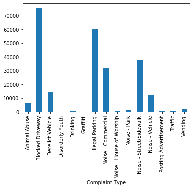

```python
df_new.groupby(['Complaint Type']).size().plot(kind='bar')
```

```python
df_new.groupby('Complaint Type').Request_Closing_Time.mean(numeric_only=False)
```

```
Complaint Type
Animal Abuse               05:21:41.111364
Blocked Driveway           04:44:23.280153
Derelict Vehicle           07:13:53.089797
Disorderly Youth           03:37:15.335135
Drinking                   03:50:35.252234
Graffiti                          05:52:09
Illegal Parking            04:28:48.593133
Noise - Commercial         03:07:39.168019
Noise - House of Worship   03:18:13.221264
Noise - Park               03:29:57.240157
Noise - Street/Sidewalk    03:29:11.489154
Noise - Vehicle            03:41:56.820491
Posting Advertisement      01:52:02.608695
Traffic                    03:55:00.942265
Vending                    03:58:30.310266
Name: Request_Closing_Time, dtype: timedelta64[ns]
```

```python
df_new['Request_Closing_Time']=pd.to_numeric(df_new.Request_Closing_Time)
```

```python
dt=pd.DataFrame(df_new.groupby('Complaint Type').Request_Closing_Time.mean(numeric_only=False))
dt
```

| Complaint Type | Request_Closing_Time |
| --- | --- |
| Animal Abuse | 1.930111e+13 |
| Blocked Driveway | 1.706328e+13 |
| Derelict Vehicle | 2.603309e+13 |
| Disorderly Youth | 1.303534e+13 |
| Drinking | 1.383525e+13 |
| Graffiti | 2.112900e+13 |
| Illegal Parking | 1.612859e+13 |
| Noise - Commercial | 1.125917e+13 |
| Noise - House of Worship | 1.189322e+13 |
| Noise - Park | 1.259724e+13 |
| Noise - Street/Sidewalk | 1.255149e+13 |
| Noise - Vehicle | 1.331682e+13 |
| Posting Advertisement | 6.722609e+12 |
| Traffic | 1.410094e+13 |
| Vending | 1.431031e+13 |

```python
dt.describe() #to generate Request time Statistics!
```

|  | Request_Closing_Time |
| --- | --- |
| count | 1.500000e+01 |
| mean | 1.488516e+13 |
| std | 4.601160e+12 |
| min | 6.722609e+12 |
| 25% | 1.257436e+13 |
| 50% | 1.383525e+13 |
| 75% | 1.659594e+13 |
| max | 2.603309e+13 |

H0:the mean is the same H1:the mean is different we'll assume confidence level of 95% therefore our Significance level will be 0.05 we have 15 number of complaint types so 15 groups, therefore we will carry out a one way anova test

```python
from scipy.stats import f_oneway
```

```python
df_sub=df_new[['Complaint Type','Request_Closing_Time']]
Animal_Abuse =[]
Blocked_Driveway=[]
Derelict_Vehicle  =[]
Disorderly_Youth=[]
Drinking=[]
Graffiti=[]
Illegal_Parking=[]
Noise_Commercial=[]
Noise_House_of_Worship=[]
Noise_Park=[]
Noise_Street_Sidewalk=[]
Noise_Vehicle=[]
Posting_Advertisement=[]
Traffic=[]
Vending=[]
j=-1
for i in df_sub['Complaint Type']:
    j=j+1

    if i=='Animal Abuse':
        Animal_Abuse.append(df_sub.Request_Closing_Time.iloc[j])

    elif i=='Blocked Driveway':
        Blocked_Driveway.append(df_sub.Request_Closing_Time.iloc[j])

    elif i=='Derelict Vehicle':
        Derelict_Vehicle.append(df_sub.Request_Closing_Time.iloc[j])

    elif i=='Disorderly Youth':
        Disorderly_Youth.append(df_sub.Request_Closing_Time.iloc[j])

    elif i=='Drinking':
        Drinking.append(df_sub.Request_Closing_Time.iloc[j])

    elif i=='Graffiti':
        Graffiti.append(df_sub.Request_Closing_Time.iloc[j])

    elif i=='Illegal Parking':
        Illegal_Parking.append(df_sub.Request_Closing_Time.iloc[j])

    elif i=='Noise - Commercial':
        Noise_Commercial.append(df_sub.Request_Closing_Time.iloc[j])

    elif i=='Noise - House of Worship':
        Noise_House_of_Worship.append(df_sub.Request_Closing_Time.iloc[j])

    elif i=='Noise - Park':
        Noise_Park.append(df_sub.Request_Closing_Time.iloc[j])

    elif i=='Noise - Street/Sidewalk':
        Noise_Street_Sidewalk.append(df_sub.Request_Closing_Time.iloc[j])

    elif i=='Noise - Vehicle':
        Noise_Vehicle.append(df_sub.Request_Closing_Time.iloc[j])

    elif i=='Posting Advertisement':
        Posting_Advertisement.append(df_sub.Request_Closing_Time.iloc[j])

    elif i=='Traffic':
        Traffic.append(df_sub.Request_Closing_Time.iloc[j])

    else:

        Vending.append(df_sub.Request_Closing_Time.iloc[j])
```

The one-way ANOVA tests the null hypothesis that two or more groups have the same population mean. The test is applied to samples from two or more groups, possibly with differing sizes.

```python
f_oneway(Animal_Abuse,Blocked_Driveway,Derelict_Vehicle,Disorderly_Youth,Drinking,Graffiti,Illegal_Parking,Noise_Commercial,Noise_House_of_Worship,Noise_Park,Noise_Street_Sidewalk,Noise_Vehicle,Posting_Advertisement,Traffic,Vending)
```

```
F_onewayResult(statistic=470.9194638970011, pvalue=0.0)
```

```python
from scipy.stats import kruskal
```

The Kruskal-Wallis H-test tests the null hypothesis that the population median of all of the groups are equal. It is a non-parametric version of ANOVA. The test works on 2 or more independent samples, which may have different sizes. Note that rejecting the null hypothesis does not indicate which of the groups differs.

```python
kruskal(Animal_Abuse,Blocked_Driveway,Derelict_Vehicle,Disorderly_Youth,Drinking,Graffiti,Illegal_Parking,Noise_Commercial,Noise_House_of_Worship,Noise_Park,Noise_Street_Sidewalk,Noise_Vehicle,Posting_Advertisement,Traffic,Vending)
```

```
KruskalResult(statistic=202342980.3577878, pvalue=0.0)
```

**Since both tests gave us a pvalue which is almost zero, ill assume it's a very small insignificant amount below the significance level and therefore i will reject the null Hypothesis and say that the average Request_Closing_Time for all 15 groups/Complaint Type are not the same!**

```python
#Now to test whether the Complaint type and location related
```

```python
import scipy
```

```python
from sklearn.preprocessing import LabelEncoder
```

```python
lb=LabelEncoder()
```

```python
df_new['Complaint Type']=lb.fit_transform(df_new['Complaint Type'])
```

```python
#We can change the location into distance from the datum by using the X coordinate and Y coordinate as shown below
```

```python
from numpy import sqrt
```

```python
df_new['Location']=sqrt(((df_new['X Coordinate (State Plane)'])**2)+(df_new['Y Coordinate (State Plane)'])**2)
```

```python
#Now we have converted both features into Numerical Attributes it's time to do the coorelation tests
```

```python
scipy.stats.pearsonr(df_new['Complaint Type'],df_new['Location'])
```

```
(-0.1256609297579054, 0.0)
```

```python
scipy.stats.spearmanr(df_new['Complaint Type'],df_new['Location'])
```

```
SpearmanrResult(correlation=-0.14047168482852304, pvalue=0.0)
```